# A QUANTUM PARTICLE MOVING IN SPACE

### Authors:

- [Vinícius Wilian D. Cruzeiro, Ph.D. Candidate](http://roitberg.chem.ufl.edu)
- [Valeria D. Kleiman, Associate Professor](http://kleiman.chem.ufl.edu/)

Department of Chemistry

Physical Chemistry Division

University of Florida

P.O. Box 117200

Gainesville, FL 32611-7200

United States

**Instructions:**

- The reader should follow this notebook in the order that it is presented, executing code cells in consecutive order.
- In order to execute a cell you may click on the cell and click the *PLAY* button, press *Shift+Enter*, or got to *Cell-->Run cells*. The user may also execute all cells at once by clicking on *Cell --> Run All* at the toolbar above.
- **Important:** Some cells **are only going to execute after the user enters input values in the corresponding boxes**.

```python
from IPython.display import HTML
```

```python
HTML('''<script>
code_show=true;
function code_toggle() {
 if (code_show){
 $('div.input').hide();
 } else {
 $('div.input').show();
 }
 code_show = !code_show
}
$( document ).ready(code_toggle);
</script>
The raw code for this IPython notebook is by default hidden for easier reading. As you scroll through code cell,
they appear as empty cells
with a blue right-side edge
To toggle on/off the raw code, click <a href="javascript:code_toggle()">here</a>.''')
```

The raw code for this IPython notebook is by default hidden for easier reading. As you scroll through code cell, they appear as empty cells with a blue right-side edge To toggle on/off the raw code, click here.

### Libraries used in this notebook:

The next cell imports all the libraries used in this notebook and calls some useful functions.

```python
import matplotlib as mpl # matplotlib library for plotting and visualization
import matplotlib.pylab as plt # matplotlib library for plotting and visualization
import numpy as np #numpy library for numerical manipulation, especially suited for data arrays
```

It is useful sometimes to shut down eventual warnings displayed by IPython. This next cell is therefore optional.

```python
import warnings
warnings.filterwarnings('ignore')
```

Executing the next cell prints on the screen the versions of IPython, Python and its libraries on your computer. Please check if the versions are up-to-date to facilitate a smooth running of the program.

The next cell configures `matplotlib` to show figures embedded within the cells it was executed from, instead of opening a new window for each figure.

```python
%matplotlib inline
```

```python
import sys # checking the version of Python
import IPython # checking the version of IPython
print("Python version = {}".format(sys.version))
print("IPython version = {}".format(IPython.__version__))
print("Matplotlib version = {}".format(plt.__version__))
print("Numpy version = {}".format(np.__version__))
```

```
Python version = 3.6.0 (default, Dec 24 2016, 08:03:08)
[GCC 6.2.1 20160830]
IPython version = 5.1.0
Matplotlib version = 1.11.3
Numpy version = 1.11.3
```

# PART I: Describing the Free Particle

```python
# Defining Psi and PsiC (complex conjugate) functions
def psi(x,k): return (1.0/np.sqrt(2.0*np.pi))*(np.cos(k*x)+np.sin(k*x)*1j)
def psiC(x,k): return (1.0/np.sqrt(2.0*np.pi))*(np.cos(k*x)-np.sin(k*x)*1j)

# Reading the input variables from the user
k = float(input("Enter the value for k (in Angstroms-1) = "))
xmax = float(input("Enter the maximum value for x (in Angstroms) = "))

# Generating the wavefunction graph
plt.rcParams.update({'font.size': 18, 'font.family': 'STIXGeneral', 'mathtext.fontset': 'stix'})
x = np.linspace(-xmax, xmax, 900)
fig, ax = plt.subplots()
lim1=1/np.sqrt(2*np.pi) # Maximum value of the wavefunction
ax.axis([-xmax,xmax,-lim1*1.1,lim1*1.1]) # Defining the limits to be plot in the graph
ax.plot(x, psi(x,k).real, label="Real", color="blue") # Ploting the real part of the wavefunction
ax.plot(x, psi(x,k).imag, label="Imag.", color="red") # Ploting the real part of the wavefunction
ax.hlines(0.0, -xmax, xmax, linewidth=1.8, linestyle='--', color="black") # Adding a horizontal line at 0
# Now we define labels, legend, etc
ax.legend(loc=2);
ax.set_xlabel(r'$x$ (Angstroms)')
ax.set_ylabel(r'$\psi_k(x)$')
str1=r"$k$ = "+str(k)+r" A$^{-1}$"
plt.title('Wavefunction for '+str1)
plt.legend(bbox_to_anchor=(1.1, 1), loc=2, borderaxespad=0.0)

# Generating the probability density graph
fig, ax = plt.subplots()
ax.axis([-xmax,xmax,0.0,lim1*lim1*1.4]) # Defining the limits to be plot in the graph
ax.plot(x, psi(x,k)*psiC(x,k),label="Probability Density", color="blue") # Plotting the probability density
# Now we define labels, legend, etc
ax.legend(loc=2);
ax.set_xlabel(r'$x$ (Angstroms)')
ax.set_ylabel(r'$\left|\psi_k(x)\right|^2$')
str1=r"$k$ = "+str(k)+r" A$^{-1}$"
plt.title('Probability Density for '+str1)
plt.legend(bbox_to_anchor=(1.1, 1), loc=2, borderaxespad=0.0)

# Show the plots on the screen once the code reaches this point
plt.show()
```

```
Enter the value for k (in Angstroms-1) =
Enter the maximum value for x (in Angstroms) =
```

[figure not shown]

**What can we conclude?:** The graphical representation shows that the wavefunction is completly *delocalized* in the x coordinate. However, wherever we look, the value of the probability density ($|\psi^*_k(x) \psi_k(x) |$) is the same.

### An interesting question to ask: what is the probability to find a free particle within a $\Delta x$ region in space?

$$\Psi^*_k(x) \Psi_k(x) \Delta x = \left|\Psi_k(x)\right|^2 \Delta x = \left(\frac{1}{\sqrt{2\pi}} e^{ikx}\right)^*\frac{1}{\sqrt{2\pi}} e^{ikx} \Delta x = \frac{1}{2\pi} \Delta x $$

The probability of finding the particle at **any** place in space,within a $\Delta x$, is constant.

Thus when the particle has a well-defined momentum ($\hbar k$), the probability of finding it anywhere in space is the same.

*Localization* of the particle can be obtained by considering not just a single value of momentum ($\hbar k$), but a range of values.

Consider the superposition of waves with $p=p_0 \pm \Delta p$ $\hspace{1cm}$ or $\hspace{1cm}$ $\hbar k = \hbar(k_0 \pm \Delta k)$

Since the momentum varies continuolsy, we use an integration to build the superposition of waves, all equally weigthed:
$$\Psi_{\Delta k}(x) =\int^{k_o+\Delta k}_{k_o-\Delta k}\ e^{ikx}dk$$

$$\Psi_{\Delta k}(x) = \frac{2\sin(\Delta kx)}{x} e^{ik_ox}$$

To understand this new wavefunction, we plot its Real and Imaginary components separately.

```python
# Defining functions
def psi_contour(x,dk): return (2.0*np.sin(dk*x)/x)
def psi(x,k,dk): return psi_contour(x,dk)*(np.cos(k*x)+np.sin(k*x)*1j)

# Reading the input variables from the user
print 'To understand this new wavefunction, we plot the Real and Imaginary components separately'
k = float(input("Enter the value for k_o (in Angstroms-1) = "))
dk = float(input("Enter the value for Delta k (in Angstroms-1) = "))
xmax = float(input("Enter the maximum value for x (in Angstroms) = "))

# Generating the wavefunction graph
lim1 = 2.0*dk
plt.rcParams.update({'font.size': 18, 'font.family': 'STIXGeneral', 'mathtext.fontset': 'stix'})
x = np.linspace(-xmax, xmax, 900)
fig, axes = plt.subplots(1, 2, figsize=(13,4))
str1=r"$k_o  \pm \Delta k$ = "+str(k)+r" $\pm$ "+str(dk)+r" A$^{-1}$"
# axes[0] is the graph at the left
axes[0].axis([-xmax,xmax,-1.1*lim1,1.1*lim1])
axes[0].plot(x, psi(x,k,dk).real, label="Real", color="blue", linewidth=1.8)
axes[0].plot(x, psi_contour(x,dk), label="", linestyle ="--",color="blue", linewidth=1.2)
axes[0].plot(x, -psi_contour(x,dk), label="", linestyle ="--",color="blue", linewidth=1.2)
axes[0].hlines(0.0, -xmax, xmax, linewidth=1.8, linestyle='--', color="black")
axes[0].set_xlabel(r'$x$ (Angstroms)')
axes[0].set_ylabel(r'$Real(\Psi_{\Delta k}(x))$')
axes[0].set_title('Real contribution to $\Psi_{\Delta k}(x)$ \n for '+str1)
# axes[1] is the graph at the right
axes[1].axis([-xmax,xmax,-1.1*lim1,1.1*lim1])
axes[1].plot(x, psi(x,k,dk).imag, label="Imag.", color="red", linewidth=1.8)
axes[1].plot(x, psi_contour(x,dk), label="", linestyle ="--",color="red", linewidth=1.2)
axes[1].plot(x, -psi_contour(x,dk), label="", linestyle ="--",color="red", linewidth=1.2)
axes[1].hlines(0.0, -xmax, xmax, linewidth=1.8, linestyle='--', color="black")
axes[1].yaxis.set_label_position("right")
axes[1].set_xlabel(r'$x$ (Angstroms)')
axes[1].set_ylabel(r'$Imag(\Psi_{\Delta k}(x))$')
axes[1].set_title('Imaginary contribution to $\Psi_{\Delta k}(x)$ \n for '+str1)

# Generating the probability density graph
fig, ax = plt.subplots()
ax.axis([-xmax,xmax,0.0,lim1*lim1*1.1]) # Defining the limits to be plot in the graph
ax.plot(x, (psi(x,k,dk).real)**2+(psi(x,k,dk).imag)**2,label="Probability Density", color="green") # Plotting the probability density
# Now we define labels, legend, etc
ax.legend(loc=2);
ax.set_xlabel(r'$x$ (Angstroms)')
ax.set_ylabel(r'$\left|\Psi_{\Delta k}(x)\right|^2$')
plt.title('Probability Density \n for '+str1)
plt.legend(bbox_to_anchor=(1.1, 1), loc=2, borderaxespad=0.0)

# Show the plots on the screen once the code reaches this point
plt.show()
```

```
To understand this new wavefunction, we plot the Real and Imaginary components separately
Enter the value for k_o (in Angstroms-1) =
Enter the value for Delta k (in Angstroms-1) =
Enter the maximum value for x (in Angstroms) =
```

[figure not shown]

Assuming $k_o > \Delta k$, the $\cos(k_o x)$ and $\sin(k_o x)$ components oscillate with a larger frequency ($k_o$, solid lines) and they are modulated by a smaller frequency ($\Delta k$, dashed lines) sinusoidal component.

If $\Delta k$ is very small, the particle is still delocalized, but as $\Delta k$ increases, the particle becomes more localized in a specific region around $x = 0$. This leads us to conclude that as the *uncertainty* in the momentum increases (larger $\Delta k$), the *uncertainty* in the position decreases, and the particle becomes more *localized*.

The superposition of waves can be accomplished by giving different contributions to different values of momenta.

For example, we can construct the superposition with a Gaussian weighting function. In this case, we modulate the contribution of each $k$-wave with a value given by a Gaussian distribution (maximum contribution from $k_o$, with smaller contributions from waves with other $k$ values).

$$\Psi_{\Delta k}(x) =\int^{+\infty}_{-\infty}{e^{-\frac{(k-k_o)^2}{2\Delta k^2}} \ e^{ikx}}dk,$$

where $\Delta k$ is related to the width of the Gaussian distribution. After integration, we obtain:

$$\Psi_{\Delta k}(x) = \sqrt{2\pi}\Delta k e^{-\frac{1}{2}x^2\Delta k^2} e^{ik_ox}$$

```python
# Defining functions
def psi_contour(x,dk): return np.sqrt(2.0*np.pi)*dk*np.exp(-0.5*x*x*dk*dk)
def psi(x,k,dk): return psi_contour(x,dk)*(np.cos(k*x)+np.sin(k*x)*1j)

# Reading the input variables from the user
print "We plot the Real and Imaginary components separately"
k = float(input("Enter the value for k_o (in Angstroms-1) = "))
dk = float(input("Enter the value for Delta k (in Angstroms-1) = "))
xmax = float(input("Enter the maximum value for x (in Angstroms) = "))

# Generating the wavefunction graph
lim1 = np.sqrt(2.0*np.pi)*dk
plt.rcParams.update({'font.size': 18, 'font.family': 'STIXGeneral', 'mathtext.fontset': 'stix'})
x = np.linspace(-xmax, xmax, 900)
fig, axes = plt.subplots(1, 2, figsize=(13,4))
str1=r"$k_o  \pm \Delta k$ = "+str(k)+r" $\pm$ "+str(dk)+r" A$^{-1}$"
# axes[0] is the graph at the left
axes[0].axis([-xmax,xmax,-1.1*lim1,1.1*lim1])
axes[0].plot(x, psi(x,k,dk).real, label="Real", color="blue")
axes[0].plot(x, psi_contour(x,dk), label="", linestyle ="--",color="blue", linewidth=1.8)
axes[0].plot(x, -psi_contour(x,dk), label="", linestyle ="--",color="blue", linewidth=1.8)
axes[0].hlines(0.0, -xmax, xmax, linewidth=1.8, linestyle='--', color="black")
axes[0].set_xlabel(r'$x$ (Angstroms)')
axes[0].set_ylabel(r'$Real(\Psi_{\Delta k}(x))$')
axes[0].set_title('Real contribution to $\Psi_{\Delta k}(x)$ \n for '+str1)
# axes[1] is the graph at the right
axes[1].axis([-xmax,xmax,-1.1*lim1,1.1*lim1])
axes[1].plot(x, psi(x,k,dk).imag, label="Imag.", color="red")
axes[1].plot(x, psi_contour(x,dk), label="", linestyle ="--",color="red", linewidth=1.8)
axes[1].plot(x, -psi_contour(x,dk), label="", linestyle ="--",color="red", linewidth=1.8)
axes[1].hlines(0.0, -xmax, xmax, linewidth=1.8, linestyle='--', color="black")
axes[1].set_xlabel(r'$x$ (Angstroms)')
axes[1].set_ylabel(r'$Imag(\Psi_{\Delta k}(x))$')
axes[1].set_title('Imaginary contribution to $\Psi_{\Delta k}(x)$ \n for '+str1)

# Generating the probability density graph
fig, ax = plt.subplots()
ax.axis([-xmax,xmax,0.0,lim1*lim1*1.1]) # Defining the limits to be plot in the graph
ax.plot(x, (psi(x,k,dk).real)**2+(psi(x,k,dk).imag)**2,label="Probability Density", color="magenta") # Plotting the probability density
# Now we define labels, legend, etc
ax.legend(loc=2);
ax.set_xlabel(r'$x$ (Angstroms)')
ax.set_ylabel(r'$\left|\Psi_{\Delta k}(x)\right|^2$')
plt.title('Probability Density \n for '+str1)
plt.legend(bbox_to_anchor=(1.1, 1), loc=2, borderaxespad=0.0)

# Show the plots on the screen once the code reaches this point
plt.show()
```

```
We plot the Real and Imaginary components separately
Enter the value for k_o (in Angstroms-1) =
Enter the value for Delta k (in Angstroms-1) =
Enter the maximum value for x (in Angstroms) =
```

[figure not shown]

We can compare the effect of using a Gaussian distribution of $k$-values versus using equally weigthed $k$-values:

Here are a few questions to consider graphically:

```python
# Defining functions
def psi_contour(x,dk): return (4.0*np.sin(dk*x)*np.sin(dk*x)/(x*x))
def psi_contourG(x,dk): return (2.0*np.pi*dk*dk*np.exp(-x*x*dk*dk))

# Reading the input variables from the user
print "What is the probability density of finding the particle as a function of position? \n"
k = float(input("Enter the value for k_o (in Angstroms-1) = "))
dk = float(input("Enter the value for Delta k (in Angstroms-1) = "))
xmax = float(input("Enter the maximum value for x (in Angstroms) = "))

# Generating the probability density graphs
lim0 = 4.0*dk*dk
lim1 = psi_contourG(0,dk)
plt.rcParams.update({'font.size': 18, 'font.family': 'STIXGeneral', 'mathtext.fontset': 'stix'})
x = np.linspace(-xmax, xmax, 900)
fig, axes = plt.subplots(1, 2, figsize=(13,4))
str1=r"$k_o \pm \Delta k$ = "+str(k)+r" $\pm$ "+str(dk)+r" A$^{-1}$"
axes[0].plot(x, psi_contour(x,dk), label="", linestyle ="-",color="green", linewidth=1.8)
axes[0].hlines(0.0, -xmax, xmax, linewidth=1.8, linestyle='--', color="black")
axes[0].axis([-xmax,xmax,-0.1*lim0,1.1*lim0])
axes[0].set_xlabel(r'$x$ (Angstroms)')
axes[0].set_ylabel(r'$\left|\Psi_k(x)\right|^2$')
axes[0].set_title('Probability Density \n for '+str1)
axes[1].plot(x, psi_contourG(x,dk), label="", linestyle ="-",color="magenta", linewidth=1.8)
axes[1].hlines(0.0, -xmax, xmax, linewidth=1.8, linestyle='--', color="black")
axes[1].axis([-xmax,xmax,-0.1*lim1,1.1*lim1])
axes[1].set_xlabel(r'$x$ (Angstroms)')
axes[1].set_ylabel(r'$\left|\Psi_k(x)\right|^2$')
axes[1].set_title('Probability Density \n for '+str1)

# Show the plots on the screen once the code reaches this point
plt.show()
```

```
What is the probability density of finding the particle as a function of position?

Enter the value for k_o (in Angstroms-1) =
Enter the value for Delta k (in Angstroms-1) =
Enter the maximum value for x (in Angstroms) =
```

[figure not shown]

**What can we conclude:** From the graphical representation we can learn that for $\Delta k$ very small compared to $k_o$ (try plotting for $k_o = 3$ $\Delta k = 0.03$), the particle is still delocalized. As $\Delta k$ increases the particle becomes more localized in a specific region around $x=0$ (i.e $k_o = 3$ $\Delta k = 0.3$ ). When $\Delta k$ is large in comparison to $k_o$ (i.e. $k_o = 3$ $ \Delta k = 0.9$), we oberve the probability density concentrated around $x=0$.

This leads us to conclude that as the uncertainty in the momentum increases (larger $\Delta k$), the uncertainty in the position decreases, and the particle becomes more localized. This is the exactly the behavior predicted by the **Heisenberg's uncertainty principle**.

### What other properties can we measure?

A Free particle has no potential (no acting force), thus the Hamiltonian only has a Kinetic term. The Schrödinger equation is:

$$-\frac{\hbar^2}{2m} \frac{\partial^2\psi(x)}{\partial x^2} =E\psi(x)$$

Since we already know an eigenfunction of the momentum operator, let's work a bit with commutator properties, and how they can be applied to the Free Particle wavefunction.

One property of commutators states that if two Hermitian operators ($\hat A$ and $\hat B$) commute, then they share a common set of eigenfunctions.

Let's now check if the Hamiltonian and the momentum operators commute, that is, if $\left[\hat P, \hat H \right] =0$. $\hat H =\frac{\hat P^2}{2m}$ thus we evaluate:

$$\left[\hat P, \hat H \right] = \hat P \cdot \hat H - \hat H \cdot \hat P$$

$$\hat P \cdot \frac{\hat P^2}{2m} - \frac{\hat P^2}{2m}\cdot \hat P = \frac {1}{2m}\left(\hat P \cdot \hat P^2-\hat P \cdot \hat P^2 \right) = 0$$

Therefore there is a complete set of eigenfunctions common to both operators. Since we already know the eigenfunctions of $\hat P$, we can try to see if they are also eigenfunctions of $\hat H$. For $\left|k\right> = \frac{1}{\sqrt{2\pi}}e^{ikx}$, let's evaluate what is the result of $\hat H \left|k\right>$:

$$\hat H\left|k\right> = -\frac{\hbar^2}{2m} \frac{\partial^2\left|k\right>}{\partial x^2} = -\frac{\hbar^2}{2m} \frac{\partial^2}{\partial x^2}\left(\frac{1}{\sqrt{2\pi}}e^{ikx} \right)$$$$\hspace 1.5cm = -\frac{\hbar^2}{2m\sqrt{2\pi}} \frac{\partial^2e^{ikx}}{\partial x^2} = -\frac{\hbar^2}{2m\sqrt{2\pi}} \left(ik\right)^2 e^{ikx}$$

$$= \frac{\hbar^2k^2}{2m} \left(\frac{1}{\sqrt{2\pi}}e^{ikx} \right) = \frac{p^2}{2m}\left|k\right>$$

The first and last terms in this derivation show that the momentum eigenfunctions are also eigenfunctions of the Hamiltonian, with eigenvalues equal to the classical form of the kinetic energy. However, one has to be beware that although the value of the energy might look *classical*, the behavior of the particles are very different. For the quantum mechanical systems, the particle can *never be at rest* (if $\Delta k = 0$ the particle is deloclaized; if the particle is very localized, then its momentum has many different values).

# PART 2: Particle in an box with infinite-potential walls

## Particle in a 1D box

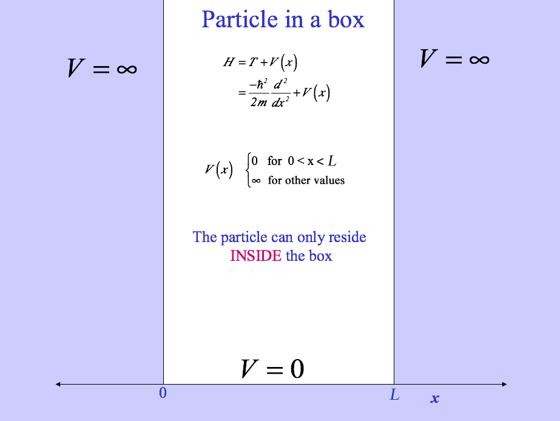

```python
from IPython.display import Image
Image(filename='particle_in_an_infinite_box_diagram.png')
```

Inside the box, the potential is equal to zero, and the Schrödinger equation for this system is given by $$\frac{-\hbar^2}{2m}\frac{\partial^2\psi_n(x)}{\partial{x}^2} =E\psi_n(x) $$

Since the potential is infinity outside the box, the wavefunction must obey the following *Boundary Conditions*: $$\psi_n(0)=\psi_n(L)=0$$

where *L* is the length of the box.

After solving the Schrödinger equation, the eigenfunctions obtained are given by: $$\psi_n(x) = \sqrt{\frac{2}{L}} sin\left(\frac{n\pi}{L}x\right) \hspace1 cm n=1, 2, ..., \infty $$ It is important to emphasize that the quantization (*n* being only positive integers) is a consequence of the boundary conditions.

We can look at the properties of the solutions by plotting both the **Wavefunction**, $\psi_n(x)$ and the **Probability Density**, $|\psi_n(x)|^2$.

Here are a few questions to consider before we move on:

- **Q1:** Can you infer, just looking at the graphical representations of $\psi_n(x)$ or $|\psi_n(x)|^2$, what is the quantum state (labeled by its quantum number) *n*?
- **Q2:** What is a node? How do the nodes relate to the Kinetic Energy of the system?
- **Q3:** Is it possible to find the particle outside the box?
- **Q4:** Does it matter that $\psi_n(x)$ has negative values?
- **Q5:** What variables and parameters does $\psi_n(x)$ depend on?

Some of these questions can be answered by plotting the **Wavefunction** and the **Probability Density** for different values of *n*:

```python
# Defining the wavefunction
def psi(x,n,L): return np.sqrt(2.0/L)*np.sin(float(n)*np.pi*x/L)

# Reading the input variables from the user
n = int(input("Enter the value for the quantum number n (must be an integer) = "))
L = float(input("Enter the size of the box in Angstroms = "))

# Generating the wavefunction graph
plt.rcParams.update({'font.size': 18, 'font.family': 'STIXGeneral', 'mathtext.fontset': 'stix'})
x = np.linspace(0, L, 900)
fig, ax = plt.subplots()
lim1=np.sqrt(2.0/L) # Maximum value of the wavefunction
ax.axis([0.0,L,-1.1*lim1,1.1*lim1]) # Defining the limits to be plot in the graph
str1=r"$n = "+str(n)+r"$"
ax.plot(x, psi(x,n,L), linestyle='--', label=str1, color="orange", linewidth=2.8) # Plotting the wavefunction
ax.hlines(0.0, 0.0, L, linewidth=1.8, linestyle='--', color="black") # Adding a horizontal line at 0
# Now we define labels, legend, etc
ax.legend(loc=2);
ax.set_xlabel(r'$L$')
ax.set_ylabel(r'$\psi_n(x)$')
plt.title('Wavefunction')
plt.legend(bbox_to_anchor=(1.1, 1), loc=2, borderaxespad=0.0)

# Generating the probability density graph
fig, ax = plt.subplots()
ax.axis([0.0,L,0.0,lim1*lim1*1.1])
str1=r"$n = "+str(n)+r"$"
ax.plot(x, psi(x,n,L)*psi(x,n,L), label=str1, linewidth=2.8)
ax.legend(loc=2);
ax.set_xlabel(r'$L$')
ax.set_ylabel(r'$|\psi_n|^2(x)$')
plt.title('Probability Density')
plt.legend(bbox_to_anchor=(1.1, 1), loc=2, borderaxespad=0.0)

# Show the plots on the screen once the code reaches this point
plt.show()
```

```
Enter the value for the quantum number n (must be an integer) =
Enter the size of the box in Angstroms =
```

[figure not shown]

We can explore the changes in the **Wavefunction** and **Probability Density** for a given state *n* and for boxes of different lengths:

```python
# Reading the input boxes sizes from the user, and making sure the values are not higher than 20 A
L = 100.0
while(L>20.0):
    L1 = float(input(" To comapre wavefunctions for boxes of different lengths \nenter the value of L for the first box  (in Angstroms, not larger then 20 A) = "))
    L2 = float(input("Enter the value of L for the second box (in Angstroms, not larger then 20 A) = "))
    L = max(L1,L2)
    if(L>20.0):
        print("The sizes of the boxes cannot be higher than 20 A. Please enter the values again.\n")

# Generating the wavefunction and probability density graphs
plt.rcParams.update({'font.size': 18, 'font.family': 'STIXGeneral', 'mathtext.fontset': 'stix'})
fig, ax = plt.subplots(figsize=(12,6))
ax.spines['right'].set_color('none')
ax.xaxis.tick_bottom()
ax.spines['left'].set_color('none')
ax.axes.get_yaxis().set_visible(False)
ax.spines['top'].set_color('none')
val = 1.1*max(L1,L2)
X1 = np.linspace(0.0, L1, 900,endpoint=True)
X2 = np.linspace(0.0, L2, 900,endpoint=True)
ax.axis([-0.5*val,1.5*val,-np.sqrt(2.0/L),3*np.sqrt(2.0/L)])
ax.set_xlabel(r'$X$ (Angstroms)')
strA="$\psi_n$"
strB="$|\psi_n|^2$"
ax.text(-0.12*val, 0.0, strA, rotation='vertical', fontsize=30, color="black")
ax.text(-0.12*val, np.sqrt(4.0/L), strB, rotation='vertical', fontsize=30, color="black")
str1=r"$L = "+str(L1)+r"$ A"
str2=r"$L = "+str(L2)+r"$ A"
ax.plot(X1,psi(X1,n,L1)*np.sqrt(L1/L), color="red", label=str1, linewidth=2.8)
ax.plot(X2,psi(X2,n,L2)*np.sqrt(L2/L), color="blue", label=str2, linewidth=2.8)
ax.plot(X1,psi(X1,n,L1)*psi(X1,n,L1)*(L1/L) + np.sqrt(4.0/L), color="red", linewidth=2.8)
ax.plot(X2,psi(X2,n,L2)*psi(X2,n,L2)*(L2/L) + np.sqrt(4.0/L), color="blue", linewidth=2.8)
ax.margins(0.00)
ax.legend(loc=9)
str2="$V = +\infty$"
ax.text(1.03*val,  0.5*np.sqrt(2.0/L), str2, rotation='vertical', fontsize=40, color="black")
ax.text(-0.3*val, 0.5*np.sqrt(2.0/L), str2, rotation='vertical', fontsize=40, color="black")
ax.vlines(0.0, -np.sqrt(2.0/L), 2.5*np.sqrt(2.0/L), linewidth=4.8, color="red")
ax.vlines(L1, -np.sqrt(2.0/L), 2.5*np.sqrt(2.0/L), linewidth=4.8, color="red")
ax.vlines(0.0, -np.sqrt(2.0/L), 2.5*np.sqrt(2.0/L), linewidth=4.8, color="blue")
ax.vlines(L2, -np.sqrt(2.0/L), 2.5*np.sqrt(2.0/L), linewidth=4.8, color="blue")
ax.hlines(0.0, 0.0, L, linewidth=1.8, linestyle='--', color="black")
ax.hlines(np.sqrt(4.0/L), 0.0, L, linewidth=1.8, linestyle='--', color="black")
plt.title('Wavefunction and Probability Density', fontsize=30)
str3=r"$n = "+str(n)+r"$"
ax.text(1.1*L,np.sqrt(4.0/L), r"$n = "+str(n)+r"$", fontsize=25, color="black")
plt.legend(bbox_to_anchor=(0.73, 0.95), loc=2, borderaxespad=0.)

# Show the plots on the screen once the code reaches this point
plt.show()
```

[output not shown]

[figure not shown]

We can also look at the **allowed values of energy**, given by: $$E_n = \frac{n^2 h^2}{8m_p L^2}$$
where $m_p$ is the mass of the particle.

**Note:** Did you notice that $\psi_n(x)$ doesn't depend on the mass of the particle?

In contrsast to the solution in the free particle system, now, not every energy value is allowed. We see that quantization is a direct consequence of the boundary conditions. In other words: confinement leads to quantization.

Let's now analyze how the *Energy Levels* $E_n$ change as a function of box size.

```python
# Defining a function to compute the energy
def En(n,L): return 37.60597*((float(n)/L)**2)

# Reading the input variables from the user
L1 = float(input(" To see how the energy levels change for boxes of different lengths, \nenter the value for L for the first box (in Angstroms) = "))
nmax1 = int(input("Enter the number of levels you want to plot for the first box = "))
L2 = float(input("Enter the value for L for the second box (in Angstroms) = "))
nmax2 = int(input("Enter the number of levels you want to plot for the second box = "))

# Generating the graph
plt.rcParams.update({'font.size': 18, 'font.family': 'STIXGeneral', 'mathtext.fontset': 'stix'})
fig, ax = plt.subplots(figsize=(8,12))
ax.spines['right'].set_color('none')
ax.yaxis.tick_left()
ax.spines['bottom'].set_color('none')
ax.axes.get_xaxis().set_visible(False)
ax.spines['top'].set_color('none')
val = 1.1*max(En(nmax1,L1),En(nmax2,L2))
val2= 1.1*max(L1,L2)
ax.axis([0.0,10.0,0.0,val])
ax.set_ylabel(r'$E_n$ (eV)')
for n in range(1,nmax1+1):
    str1="$n = "+str(n)+r"$, $E_{"+str(n)+r"} = %.3f$ eV"%(En(n,L1))
    ax.text(0.6, En(n,L1)+0.01*val, str1, fontsize=16, color="red")
    ax.hlines(En(n,L1), 0.0, 4.5, linewidth=1.8, linestyle='--', color="red")
for n in range(1,nmax2+1):
    str1="$n = "+str(n)+r"$, $E_{"+str(n)+r"} = %.3f$ eV"%(En(n,L2))
    ax.text(6.2, En(n,L2)+0.01*val, str1, fontsize=16, color="blue")
    ax.hlines(En(n,L2), 5.5, 10.0, linewidth=1.8, linestyle='--', color="blue")
str1=r"$L = "+str(L1)+r"$ A"
plt.title("Energy Levels \n ", fontsize=30)
str1=r"$L = "+str(L1)+r"$ A"
str2=r"$L = "+str(L2)+r"$ A"
ax.text(1.5,val, str1, fontsize=25, color="red")
ax.text(6,val, str2, fontsize=25, color="blue")

# Show the plots on the screen once the code reaches this point
plt.show()
```

```
 To see how the energy levels change for boxes of different lengths,
Enter the value for L for the first box (in Angstroms) =
Enter the number of levels you want to plot for the first box =
Enter the value for L for the second box (in Angstroms) =
Enter the number of levels you want to plot for the second box =
```

[figure not shown]

We can also compare the wavefunctions and the probability densities for different states of the same box size:

```python
# Here the users inputs the value of L
L = float(input("Enter the value of L (in Angstroms) = "))
nmax = int(input("Enter the maximum value of n you want to plot = "))

# Generating the wavefunction graph
fig, ax = plt.subplots(figsize=(12,9))
ax.spines['right'].set_color('none')
ax.xaxis.tick_bottom()
ax.spines['left'].set_color('none')
ax.axes.get_yaxis().set_visible(False)
ax.spines['top'].set_color('none')
X3 = np.linspace(0.0, L, 900,endpoint=True)
Emax = En(nmax,L)
amp = (En(2,L)-En(1,L)) *0.9
Etop = (Emax+amp)*1.1
ax.axis([-0.5*L,1.5*L,0.0,Etop])
ax.set_xlabel(r'$X$ (Angstroms)')

for n in range(1,nmax+1):
    ax.hlines(En(n,L), 0.0, L, linewidth=1.8, linestyle='--', color="black")
    str1="$n = "+str(n)+r"$, $E_{"+str(n)+r"} = %.3f$ eV"%(En(n,L))
    ax.text(1.03*L, En(n,L), str1, fontsize=16, color="black")
    ax.plot(X3,En(n,L)+amp*np.sqrt(L/2.0)*psi(X3,n,L), color="red", label="", linewidth=2.8)
ax.margins(0.00)
ax.vlines(0.0, 0.0, Etop, linewidth=4.8, color="blue")
ax.vlines(L, 0.0, Etop, linewidth=4.8, color="blue")
ax.hlines(0.0, 0.0, L, linewidth=4.8, color="blue")
plt.title('Wavefunctions', fontsize=30)
plt.legend(bbox_to_anchor=(0.8, 1), loc=2, borderaxespad=0.)
str2="$V = +\infty$"
ax.text(-0.15*L, 0.6*Emax, str2, rotation='vertical', fontsize=40, color="black")

# Generating the probability density graph
fig, ax = plt.subplots(figsize=(12,9))
ax.spines['right'].set_color('none')
ax.xaxis.tick_bottom()
ax.spines['left'].set_color('none')
ax.axes.get_yaxis().set_visible(False)
ax.spines['top'].set_color('none')
X3 = np.linspace(0.0, L, 900,endpoint=True)
Emax = En(nmax,L)
ax.axis([-0.5*L,1.5*L,0.0,Etop])
ax.set_xlabel(r'$X$ (Angstroms)')
for n in range(1,nmax+1):
    ax.hlines(En(n,L), 0.0, L, linewidth=1.8, linestyle='--', color="black")
    str1="$n = "+str(n)+r"$, $E_{"+str(n)+r"} = %.3f$ eV"%(En(n,L))
    ax.text(1.03*L, En(n,L), str1, fontsize=16, color="black")
    ax.plot(X3,En(n,L)+ amp*(np.sqrt(L/2.0)*psi(X3,n,L))**2, color="red", label="", linewidth=2.8)
ax.margins(0.00)
ax.vlines(0.0, 0.0, Etop, linewidth=4.8, color="blue")
ax.vlines(L, 0.0, Etop, linewidth=4.8, color="blue")
ax.hlines(0.0, 0.0, L, linewidth=4.8, color="blue")
plt.title('Probability Density', fontsize=30)
plt.legend(bbox_to_anchor=(0.8, 1), loc=2, borderaxespad=0.)
str2="$V = +\infty$"
ax.text(-0.15*L, 0.6*Emax, str2, rotation='vertical', fontsize=40, color="black")

# Show the plots on the screen once the code reaches this point
plt.show()
```

```
Enter the value of L (in Angstroms) =
Enter the maximum value of n you want to plot =
```

[figure not shown]

## Particle in a 2D box

Since the Hamiltonian can be separated into two hamiltonians, one depending only on the variable *x* and one depending only on the variable *y*, the solution to the 2D wavefunction is the product of the 1D solutions in the *x* and *y* directions, with **independent quantum numbers** *n* and *m*: $$\Psi_{n,m}(x,y) = \psi_{n}(x) \psi_{m}(y) =\frac{2}{\sqrt{L_xL_y}} sin\left(\frac{n\pi}{L_x}x\right) sin\left(\frac{m\pi}{L_y}y\right)$$

```python
# Defining the wavefunction
def psi2D(x,y): return 2.0*np.sin(n*np.pi*x)*np.sin(m*np.pi*y)

# Here the users inputs the values of n and m
n = int(input("Let's look at the Wavefunction for a 2D box \nEnter the value for n = "))
m = int(input("Enter the value for m = "))

# Generating the wavefunction graph
x = np.linspace(0, 1, 100)
y = np.linspace(0, 1, 100)
X, Y = np.meshgrid(x, y)
fig, axes = plt.subplots(1, 1, figsize=(8,8))
axes.imshow(psi2D(X,Y), origin='lower', extent=[0.0, 1.0, 0.0, 1.0])
axes.set_title(r'Heat plot of $\Psi_{n,m}(x,y)$ for $n='+str(n)+r'$ and $m='+str(m)+r'$')
axes.set_ylabel(r'$y/L_y$')
axes.set_xlabel(r'$x/L_x$')

# Plotting the colorbar for the density plots
fig = plt.figure(figsize=(10,3))
colbar = fig.add_axes([0.05, 0.80, 0.7, 0.10])
norm = mpl.colors.Normalize(vmin=0., vmax=2.0)
mpl.colorbar.ColorbarBase(colbar, norm=norm, orientation='horizontal')

# Show the plots on the screen once the code reaches this point
plt.show()
```

```
Let's look at the Wavefunction for a 2D box
Enter the value for n =
Enter the value for m =
```

[figure not shown]

Since the variables are independent, a vertical slice in this plot shows the *y* dependence of the wavefunction, thus it would look like a 1D particle in a box. Similarly, a horizontal slice gives the *x* dependence, and behaves as a 1D wavefunction.

Here are some questions to consider from the plots:

- **Q1:** How many nodes does $\Psi_{n,m}$ have in the *x* axis?, which quantum number is associated with this number?
- **Q2:** How many nodes does $\Psi_{n,m}$ have in the *y* axis?, which quantum number is associated with this number?
- **Q3:** Can you draw the equivalent picture for a non-symmetric box?

How about the energies?  
For independent variables, the energy will be the sum of the 1D energies:

$$E_{n,m} = \frac{ h^2}{8m_p}\left(\frac{n^2}{L_x^2}+\frac{m^2}{L_y^2}\right)$$

We see that, depending of the values of $L_x$ and $L_y$ (the lenght of the box on each side), we may get **degenerated states**, that is, more than one state with the same energy.

Let's look at these Energy Levels as a function of quantum numbers and box sizes:

```python
# Defining the energy as a function
def En2D(n,m,L1,L2): return 37.60597*((float(n)/L1)**2+ (float(m)/L2)**2)

# Reading data from the user
L1 = float(input("Can we count DEGENERATE states?\nEnter the value for Lx (in Angstroms) = "))
nmax1 = int(input("Enter the maximum value of n to consider = "))
L2 = float(input("Enter the value for Ly (in Angstroms) = "))
mmax2 = int(input("Enter the maximum value of m to consider = "))

# Plotting the energy levels
plt.rcParams.update({'font.size': 18, 'font.family': 'STIXGeneral', 'mathtext.fontset': 'stix'})
fig, ax = plt.subplots(figsize=(nmax1*2+2,nmax1*3))
ax.spines['right'].set_color('none')
ax.yaxis.tick_left()
ax.spines['bottom'].set_color('none')
ax.axes.get_xaxis().set_visible(False)
ax.spines['top'].set_color('none')
val = 1.1*(En2D(nmax1,mmax2,L1,L2))
val2= 1.1*max(L1,L2)
ax.axis([0.0,3*nmax1,0.0,val])
ax.set_ylabel(r'$E_n$ (eV)')
for n in range(1,nmax1+1):
    for m in range(1, mmax2+1):
        #str1="$n,m = "+str(n)+r","+str(m)+r"$"
        str1="$"+str(n)+r","+str(m)+r"$"
        str2=" $E = %.3f$ eV"%(En2D(n,m,L1,L2))
        ax.text(n*2-1.8, En2D(n,m,L1,L2)+ 0.005*val, str1, fontsize=16, color="blue")
        ax.hlines(En2D(n,m,L1,L2), n*2-2, n*2-1, linewidth=3.8, color="red")
        ax.hlines(En2D(n,m,L1,L2), 0.0, nmax1*2+1, linewidth=1., linestyle='--', color="black")
        ax.text(nmax1*2+1, En2D(n,m,L1,L2)+ 0.005*val, str2, fontsize=16, color="blue")
plt.title("Energy Levels for \n ", fontsize=30)
str1=r"$L_x = "+str(L1)+r"$ A, $n_{max} = "+str(nmax1)+r"$     $L_y = "+str(L2)+r"$ A,  $m_{max}="+str(mmax2)+r"$"
ax.text(1.5,val, str1, fontsize=25, color="black")
# Show the plots on the screen once the code reaches this point
plt.show()
```

```
Can we count DEGENERATE states?
Enter the value for Lx (in Angstroms) =
Enter the maximum value of n to consider =
Enter the value for Ly (in Angstroms) =
Enter the maximum value of m to consider =
```

[figure not shown]

Each state is represented by $(n,m)$. Notice that, for example, states (2,3) and (3,2) have the same energies, but their properties are different since the number of nodes in one direction is different than the number of nodes in the other direction.

The quantum numbers indetify individual states, whereas the energies are associated with levels.

# PART 3: Particle in a box with finite-potential walls

## Approaching the problem

Consider now the case in which the walls do not have infinite Potential heigth. Instead, they reach a maximum value $V_o$

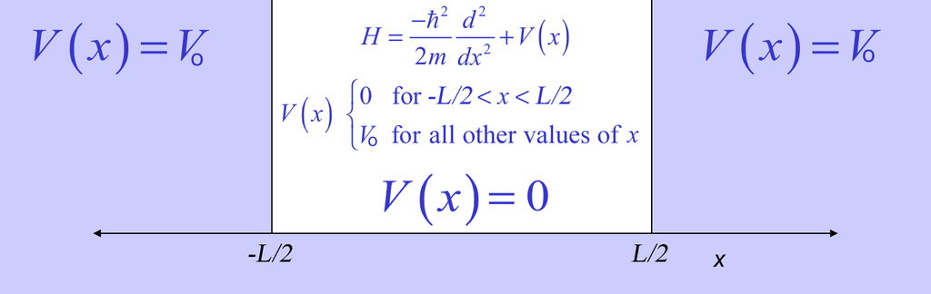

```python
from IPython.display import Image
Image(filename='particle_in_a_finite_box_diagram.png')
```

Note that the exponential function doesn't require an imaginary component $\Rightarrow$ it is not oscillatory $\psi(x) =e^{-\alpha_o |x|} $

Before we move on, here are some questions to consider:

- **Q1:** Can you test if this is a solution to the differential equation?
- **Q2** Can you write the **general solution** por a particle outside the box.
- **Q3:** What is the value of $\alpha_o$?
- **Q4:** What is the constrain for $x\rightarrow -\infty$? (Hint: $\psi(x)$ must be finite)
- **Q5:** What is the constrain for $x\rightarrow \infty$? (Hint: $\psi(x)$ must be finite)

where:

$$\alpha_o = \frac{\sqrt{2m(V_o-E)}}{\hbar} \hspace 3cm k = \frac{\sqrt{2mE}}{\hbar}$$

The wavefunction must obey the following **boundary conditions**:

$\large{\psi_{I}\left(\frac{-L}{2}\right) = \psi_{II}\left(\frac{-L}{2}\right)} \hspace 1cm $ and $ \hspace 1cm \large{\psi_{II}\left(\frac{L}{2}\right) = \psi_{III}\left(\frac{L}{2}\right)}$

$\large{\psi^{'}_{I}\left(\frac{-L}{2}\right) = \psi^{'}_{II}\left(\frac{-L}{2}\right)} \hspace 1cm $ and $ \hspace 1cm \large{\psi^{'}_{II}\left(\frac{L}{2}\right) = \psi^{'}_{III}\left(\frac{L}{2}\right)}$

where $\psi^{'} = \frac{d\psi}{dx}$.

**Note:** $\psi^{'}$ needs to be continuous to guarantee the existence of $\psi^{''}$, whose existence is required from the first postulate. $\psi^{''}$ is a component of the kinetic energy operator. If the wavefucntion doesn't have a well-defined second derivative, then the kinetic energy would be undefined, which is not possible.

It can be shown that when the potential is even (that is, when $V(-x) = V(x)$), the wavefunctions need to be either even $[\psi(-x) = \psi(x)]$ or odd $[\psi(-x) = -\psi(x)]$. The way the potential is written, we are considering that the particle is in a finite box with an even potential. Thus even and odd solutions of the wavefucntion can be found independently:

**Even solution:** $$\begin{array} {ll} \mbox{For } x \leq\frac{-L}{2}: & \psi_{I}(x) = A e^{\alpha_o x} \\ \mbox{For } \frac{-L}{2} \geq x \leq\frac{-L}{2}: & \psi_{II}(x) = B \cos(k x) \\ \mbox{For } x \leq\frac{L}{2}: & \psi_{III}(x) = D e^{-\alpha_o x}\end{array} $$ After imposing the boundary conditions we reach the following relation: $$\alpha_o = k\tan\left(k\frac{L}{2}\right)\hspace 1cm \Rightarrow \hspace 1cm \sqrt{V_o-E} = \sqrt{E}\tan\left(\frac{L\sqrt{2mE}}{2\hbar}\right) \tag{2}$$

**Odd solution:** $$\begin{array} {ll} \mbox{For } x \leq\frac{-L}{2}: & \psi_{I}(x) = A e^{\alpha_o x} \\ \mbox{For } \frac{-L}{2} \geq x \leq\frac{-L}{2}: & \psi_{II}(x) = C \sin(k x) \\ \mbox{For } x \leq\frac{L}{2}: & \psi_{III}(x) = D e^{-\alpha_o x}\end{array} $$ After imposing the boundary conditions we reach the following relation: $$\alpha_o = -\frac{k}{\tan\left(k\frac{L}{2}\right)} \hspace 1cm \Rightarrow \hspace 1cm \sqrt{V_o-E} = -\frac{\sqrt{E}}{\tan\left(\frac{L\sqrt{2mE}}{2\hbar}\right)}\tag{3}$$

The actual solution will be those corresponding to energies that obey the above equations.

## Finding the allowed Energies graphically

In this case, we cannot find the allowed energies analytically, but we can do it graphically (first) or numerically (later). That is: we can graph the left and right hand side equations $2$ and $3$ and look for the intersection points. Those will correspond to the allowed energy values.

```python
# Reading the input variables from the user
Vo = float(input("Enter the value for Vo (in eV) = "))
L =  float(input("Enter the value for L (in Angstroms) = "))

val = np.sqrt(2.0*9.10938356e-31*1.60217662e-19)*1e-10/(2.0*1.05457180013e-34) # equal to sqrt(2m*1eV)*1A/(2*hbar)

# Generating the graph
plt.rcParams.update({'font.size': 18, 'font.family': 'STIXGeneral', 'mathtext.fontset': 'stix'})
fig, axes = plt.subplots(1, 2, figsize=(13,4))
axes[0].axis([0.0,Vo,0.0,np.sqrt(Vo)*1.8])
axes[0].set_xlabel(r'$E$ (eV)')
axes[0].set_ylabel(r'(eV$^{-1}$)')
axes[0].set_title('Even solution')
axes[1].axis([0.0,Vo,0.0,np.sqrt(Vo)*1.8])
axes[1].set_xlabel(r'$E$ (eV)')
axes[1].set_ylabel(r'')
axes[1].set_title('Odd solution')
E = np.linspace(0.0, Vo, 10000)
num = int(round((L*np.sqrt(Vo)*val-np.pi/2.0)/np.pi))
# Removing discontinuity points
for n in range(10000):
    for m in range(num+2):
        if abs(E[n]-((2.0*float(m)+1.0)*np.pi/(2.0*L*val))**2)<0.01: E[n] = np.nan
        if abs(E[n]-(float(m)*np.pi/(L*val))**2)<0.01: E[n] = np.nan
# Plotting the curves and setting the labels
axes[0].plot(E, np.sqrt(Vo-E), label=r"$\sqrt{V_o-E}$", color="blue", linewidth=1.8)
axes[0].plot(E, np.sqrt(E)*np.tan(L*np.sqrt(E)*val), label=r"$\sqrt{E}\tan(\frac{L\sqrt{2mE}}{2\hbar})$", color="red", linewidth=1.8)
axes[1].plot(E, np.sqrt(Vo-E), label=r"$\sqrt{V_o-E}$", color="blue", linewidth=1.8)
axes[1].plot(E, -np.sqrt(E)/np.tan(L*np.sqrt(E)*val), label=r"$-\frac{\sqrt{E}}{\tan(\frac{L\sqrt{2mE}}{2\hbar})}$", color="red", linewidth=1.8)
# Chosing the positions of the legends
axes[0].legend(bbox_to_anchor=(0.05, -0.2), loc=2, borderaxespad=0.0)
axes[1].legend(bbox_to_anchor=(0.05, -0.2), loc=2, borderaxespad=0.0)

# Show the plots on the screen once the code reaches this point
plt.show()
```

```
Enter the value for Vo (in eV) =
Enter the value for L (in Angstroms) =
```

[figure not shown]

The allowed values would then be the values of $E$ in which the two curves cross. Here are some question to think about:

- **Q1:** How many bound states there are?
- **Q2:** How many bound states are even and how many are odd?
- **Q3:** Does the ground state has an even or an odd wavefunction?
- **Q4:** Can you read accuretely the allowed values of energy from these graphs?

The allowed values of $E$ can be also be found by numerically, yielding:

```python
print "The allowed bounded energies are:"
# We want to find the values of E in which f_even and f_odd are zero
f_even = lambda E : np.sqrt(Vo-E)-np.sqrt(E)*np.tan(L*np.sqrt(E)*val)
f_odd = lambda E : np.sqrt(Vo-E)+np.sqrt(E)/np.tan(L*np.sqrt(E)*val)
E_old = 0.0
f_even_old = f_even(0.0)
f_odd_old = f_odd(0.0)
n = 1
E_vals = np.zeros(999)
# Here we loop from E = 0 to E = Vo seeking roots
for E in np.linspace(0.0, Vo, 20000):
    f_even_now = f_even(E)
    # If the difference is zero or if it changes sign then we might have passed through a root
    if f_even_now == 0.0 or f_even_now/f_even_old < 0.0:
        # If the old values of f are not close to zero, this means we didn't pass through a root but
        # through a discontinuity point
        if (abs(f_even_now)<1.0 and abs(f_even_old)<1.0):
            E_vals[n-1] = (E+E_old)/2.0
            print "  State #%3d (Even): %9.4f eV, %13.6g J" % (n,E_vals[n-1],E_vals[n-1]*1.60217662e-19)
            n += 1
    f_odd_now = f_odd(E)
    # If the difference is zero or if it changes sign then we might have passed through a root
    if f_odd_now == 0.0 or f_odd_now/f_odd_old < 0.0:
        # If the old values of f are not close to zero, this means we didn't pass through a root but
        # through a discontinuity point
        if (abs(f_odd_now)<1.0 and abs(f_odd_old)<1.0):
            E_vals[n-1] = (E+E_old)/2.0
            print "  State #%3d  (Odd): %9.4f eV, %13.6g J" % (n,E_vals[n-1],E_vals[n-1]*1.60217662e-19)
            n += 1
    E_old = E
    f_even_old = f_even_now
    f_odd_old = f_odd_now
nstates = n-1
print "\nTHERE ARE %3d POSSIBLE BOUNDED ENERGIES" % nstates
```

[output not shown]

**Plotting an Energy Diagram helps us to see the energy separation between the states.**

```python
# Generating the energy diagram
fig, ax = plt.subplots(figsize=(8,12))
ax.spines['right'].set_color('none')
ax.yaxis.tick_left()
ax.spines['bottom'].set_color('none')
ax.axes.get_xaxis().set_visible(False)
ax.spines['top'].set_color('none')
ax.axis([0.0,10.0,0.0,1.1*Vo])
ax.set_ylabel(r'$E_n$ (eV)')
for n in range(1,nstates+1):
    str1="$n = "+str(n)+r"$, $E_"+str(n)+r" = %.3f$ eV"%(E_vals[n-1])
    ax.text(6.5, E_vals[n-1]-0.005*Vo, str1, fontsize=16, color="red")
    ax.hlines(E_vals[n-1], 0.0, 6.3, linewidth=1.8, linestyle='--', color="red")
str1="$V_o = %.3f$ eV"%(Vo)
ax.text(6.5, Vo-0.01*Vo, str1, fontsize=16, color="blue")
ax.hlines(Vo, 0.0, 6.3, linewidth=1.8, linestyle='-', color="blue")
ax.hlines(0.0, 0.0, 10.3, linewidth=1.8, linestyle='-', color="black")
plt.title("Energy Levels", fontsize=30)
plt.show()
```

[output not shown]

[figure not shown]

We can plug the values of $E$ back into the wavefunction expressions and plot the **wavefunctions** together with their corresponding **probability densities**.

```python
print "\nThe bound wavefunctions are:"
fig, ax = plt.subplots(figsize=(12,9))
ax.spines['right'].set_color('none')
ax.xaxis.tick_bottom()
ax.spines['left'].set_color('none')
ax.axes.get_yaxis().set_visible(False)
ax.spines['top'].set_color('none')
X_lef = np.linspace(-L, -L/2.0, 900,endpoint=True)
X_mid = np.linspace(-L/2.0, L/2.0, 900,endpoint=True)
X_rig = np.linspace(L/2.0, L, 900,endpoint=True)
ax.axis([-L,L,0.0,1.1*Vo])
ax.set_xlabel(r'$X$ (Angstroms)')
str1="$V_o = %.3f$ eV"%(Vo)
ax.text(1.05*L/2.0, 1.02*Vo, str1, fontsize=24, color="blue")
# Defining the maximum amplitude of the wavefunction
if (nstates > 1):
    amp = np.sqrt((E_vals[1]-E_vals[0])/1.5)
else:
    amp = np.sqrt((Vo-E_vals[0])/1.5)
# Plotting the wavefunctions
for n in range(1,nstates+1):
    ax.hlines(E_vals[n-1], -L, L, linewidth=1.8, linestyle='--', color="black")
    str1="$n = "+str(n)+r"$, $E_"+str(n)+r" = %.3f$ eV"%(E_vals[n-1])
    ax.text(1.2*L/2.0, E_vals[n-1]+0.01*Vo, str1, fontsize=16, color="black")
    k = 2.0*np.sqrt(E_vals[n-1])*val
    a0 = 2.0*np.sqrt(Vo-E_vals[n-1])*val
    # Plotting odd wavefunction
    if (n%2==0):
        ax.plot(X_lef,E_vals[n-1]-amp*np.exp(a0*L/2.0)*np.sin(k*L/2.0)*np.exp(a0*X_lef), color="red", label="", linewidth=2.8)
        ax.plot(X_mid,E_vals[n-1]+amp*np.sin(k*X_mid), color="red", label="", linewidth=2.8)
        ax.plot(X_rig,E_vals[n-1]+amp*np.exp(a0*L/2.0)*np.sin(k*L/2.0)*np.exp(-a0*X_rig), color="red", label="", linewidth=2.8)
    # Plotting even wavefunction
    else:
        ax.plot(X_lef,E_vals[n-1]+amp*np.exp(a0*L/2.0)*np.cos(k*L/2.0)*np.exp(a0*X_lef), color="red", label="", linewidth=2.8)
        ax.plot(X_mid,E_vals[n-1]+amp*np.cos(k*X_mid), color="red", label="", linewidth=2.8)
        ax.plot(X_rig,E_vals[n-1]+amp*np.exp(a0*L/2.0)*np.cos(k*L/2.0)*np.exp(-a0*X_rig), color="red", label="", linewidth=2.8)
ax.margins(0.00)
ax.vlines(-L/2.0, 0.0, Vo, linewidth=4.8, color="blue")
ax.vlines(L/2.0, 0.0, Vo, linewidth=4.8, color="blue")
ax.hlines(0.0, -L/2.0, L/2.0, linewidth=4.8, color="blue")
ax.hlines(Vo, -L, -L/2.0, linewidth=4.8, color="blue")
ax.hlines(Vo, L/2.0, L, linewidth=4.8, color="blue")
plt.title('Wavefunctions', fontsize=30)
plt.legend(bbox_to_anchor=(0.8, 1), loc=2, borderaxespad=0.)
plt.show()
```

[output not shown]

[figure not shown]

```python
print "\nThe bound Probability Densities are also shown,"
print  "with the areas shaded in green representing the region where the particle undergoes tunneling"
fig, ax = plt.subplots(figsize=(12,9))
ax.spines['right'].set_color('none')
ax.xaxis.tick_bottom()
ax.spines['left'].set_color('none')
ax.axes.get_yaxis().set_visible(False)
ax.spines['top'].set_color('none')
X_lef = np.linspace(-L, -L/2.0, 900,endpoint=True)
X_mid = np.linspace(-L/2.0, L/2.0, 900,endpoint=True)
X_rig = np.linspace(L/2.0, L, 900,endpoint=True)
ax.axis([-L,L,0.0,1.1*Vo])
ax.set_xlabel(r'$X$ (Angstroms)')
str1="$V_o = %.3f$ eV"%(Vo)
ax.text(1.05*L/2.0, 1.02*Vo, str1, fontsize=24, color="blue")
# Defining the maximum amplitude of the probability density
if (nstates > 1):
    amp = (E_vals[1]-E_vals[0])/1.5
else:
    amp = (Vo-E_vals[0])/1.5
# Plotting the probability densities
for n in range(1,nstates+1):
    ax.hlines(E_vals[n-1], -L, L, linewidth=1.8, linestyle='--', color="black")
    str1="$n = "+str(n)+r"$, $E_"+str(n)+r" = %.3f$ eV"%(E_vals[n-1])
    ax.text(1.2*L/2.0, E_vals[n-1]+0.01*Vo, str1, fontsize=16, color="black")
    k = 2.0*np.sqrt(E_vals[n-1])*val
    a0 = 2.0*np.sqrt(Vo-E_vals[n-1])*val
    # Plotting odd probability densities
    if (n%2==0):
        Y_lef = E_vals[n-1]+amp*(np.exp(a0*L/2.0)*np.sin(k*L/2.0)*np.exp(a0*X_lef))**2
        ax.plot(X_lef,Y_lef, color="red", label="", linewidth=2.8)
        ax.fill_between(X_lef, E_vals[n-1], Y_lef, color="green")
        ax.plot(X_mid,E_vals[n-1]+amp*(np.sin(k*X_mid))**2, color="red", label="", linewidth=2.8)
        Y_rig = E_vals[n-1]+amp*(np.exp(a0*L/2.0)*np.sin(k*L/2.0)*np.exp(-a0*X_rig))**2
        ax.plot(X_rig,Y_rig, color="red", label="", linewidth=2.8)
        ax.fill_between(X_rig, E_vals[n-1], Y_rig, color="green")
    # Plotting even probability densities
    else:
        Y_lef = E_vals[n-1]+amp*(np.exp(a0*L/2.0)*np.cos(k*L/2.0)*np.exp(a0*X_lef))**2
        ax.plot(X_lef,Y_lef, color="red", label="", linewidth=2.8)
        ax.fill_between(X_lef, E_vals[n-1], Y_lef, color="green")
        ax.plot(X_mid,E_vals[n-1]+amp*(np.cos(k*X_mid))**2, color="red", label="", linewidth=2.8)
        Y_rig = E_vals[n-1]+amp*(np.exp(a0*L/2.0)*np.cos(k*L/2.0)*np.exp(-a0*X_rig))**2
        ax.plot(X_rig,Y_rig, color="red", label="", linewidth=2.8)
        ax.fill_between(X_rig, E_vals[n-1], Y_rig, color="green")
ax.margins(0.00)
ax.vlines(-L/2.0, 0.0, Vo, linewidth=4.8, color="blue")
ax.vlines(L/2.0, 0.0, Vo, linewidth=4.8, color="blue")
ax.hlines(0.0, -L/2.0, L/2.0, linewidth=4.8, color="blue")
ax.hlines(Vo, -L, -L/2.0, linewidth=4.8, color="blue")
ax.hlines(Vo, L/2.0, L, linewidth=4.8, color="blue")
plt.title('Probability Densities', fontsize=30)
plt.legend(bbox_to_anchor=(0.8, 1), loc=2, borderaxespad=0.)
plt.show()
```

```
The bound Probability Densities are also shown,
with the areas shaded in green representing the region where the particle undergoes tunneling
```

[output not shown]

[figure not shown]

If we compare these results with those of a particle in a similar size box, but with infinite potential, we can see that the levels are shifted to lower energies when the potential is finite. We can also oberve that the wavefucntion and the probability density have non-zero values outside the box limits.

Classically, the particle cannot be found outside the box because the available energy is lower than the potential wall ($E < V_o$). However, for the particle in the finite box the wavefunction is nonzero outside the box, which means that there is a possibility of finding the particle outside the box. This is a pure quantum effect called the **tunneling effect**.

The tunneling probability correspond to the area outside the box that has non-zero values of probability density. In the graphicaly representation, those areas are shaded in green. The integration of those areas provide the probability that the particle will tunnel outside the classically allowed region.

It corresponds to: $$ \large{ \frac{\int^{\frac{-L}{2}}_{-\infty} |\psi(x)|^2\ dx +\int^{+\infty}_{\frac{L}{2}} |\psi(x)|^2\ dx }{\int_{-\infty}^{+\infty} |\psi(x)|^2\ dx } }$$

This integral can be solved analytically (for the even and for the odd solutions). After doing that, the tunneling probability for each state is:

```python
print "\nThe tunneling probabilities are:"
for n in range(1,nstates+1):
    k = 2.0*np.sqrt(E_vals[n-1])*val
    a0 = 2.0*np.sqrt(Vo-E_vals[n-1])*val
    # For odd solution
    if (n%2==0):
        C = 1.0
        D = np.exp(a0*L/2.0)*np.sin(k*L/2.0)*C
        prob = D*D*2.0*k*np.exp(-a0*L)/(B*B*a0*(k*L-np.sin(k*L))+D*D*2.0*k*np.exp(-a0*L))
    # For even solution
    else:
        B = 1.0
        D = np.exp(a0*L/2.0)*np.cos(k*L/2.0)*B
        prob = D*D*2.0*k*np.exp(-a0*L)/(B*B*a0*(k*L+np.sin(k*L))+D*D*2.0*k*np.exp(-a0*L))
    print "  State #%3d tunneling probability = %5.2f%%" % (n,100*prob)
```

```
The tunneling probabilities are:
  State #  1 tunneling probability =  0.59%
  State #  2 tunneling probability =  2.50%
  State #  3 tunneling probability =  6.29%
  State #  4 tunneling probability = 14.02%
  State #  5 tunneling probability = 48.29%
```

These evaluation and graphical representations show that the tunneling probability increases as the energy of the particle increases. This behavior is expected because, the higher the energy is, the lower the difference $V_o-E$ is, thus it becomes easier for the tunneling to happen.

Try evaluating these tunneling probabilities for different heights of the walls (different $V_o$ values)

# PART 4: Particle in a box with two finite-potential external walls and a barrier between them

## Approaching the problem

We can extend the calculations for the particle in a finite potential box to a potential that contains two finite boxes intermediated by a barrier with a different finite potential.

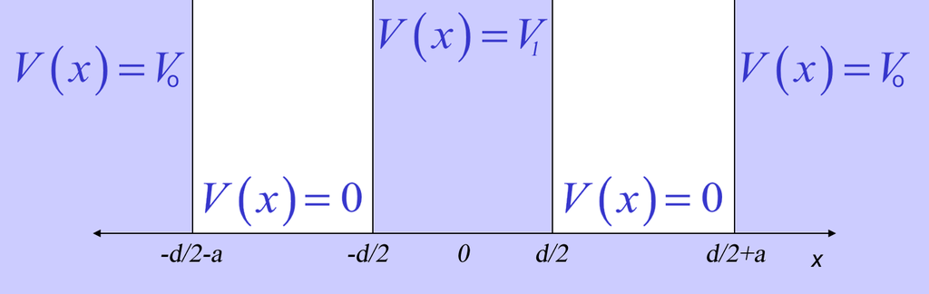

```python
from IPython.display import Image
Image(filename='particle_in_a_two_finite_boxes_diagram.png')
```

Or mathematically:

$V(x) = \left\{ \begin{array}{ll} V_1 & \mbox{if } |x| < \frac{d}{2} \\ 0 & \mbox{if } \frac{d}{2} < |x| < \frac{d}{2}+a \\ V_o & \mbox{if } |x| > \frac{d}{2}+a \end{array} \right.$

For simplicity, **we will only consider the case in which $V_1 \geq V_o$**.

For the case where $E \leq V_o$, we look for the bound states

Since the potential is even $[V(-x) = V(x)]$, the wavefunctions will be even $[\psi(-x) = \psi(x)]$ or odd $[\psi(-x) = -\psi(x)]$. considering that the wavefucntions must be finite, we obtain

**Even solution: $\psi(x) = \psi(-x)$** $$\begin{array} {ll} \mbox{For } 0 \leq x \leq \frac{d}{2}: & \psi(x) = A(e^{\alpha_1 x}+e^{-\alpha_1 x}) \\ \mbox{For } \frac{d}{2} \leq x \leq \frac{d}{2}+a: & \psi(x) = B\cos(kx) + C\sin(kx) \\ \mbox{For } x \geq \frac{d}{2}+a: & \psi(x) = De^{-\alpha_o x} \end{array} $$

**Odd solution: $\psi(x) = -\psi(-x)$** $$\begin{array} {ll} \mbox{For } 0 \leq x \leq \frac{d}{2}: & \psi(x) = A(e^{\alpha_1 x}-e^{-\alpha_1 x}) \\ \mbox{For } \frac{d}{2} \leq x \leq \frac{d}{2}+a: & \psi(x) = B\cos(kx) + C\sin(kx) \\ \mbox{For } x \geq \frac{d}{2}+a: & \psi(x) = De^{-\alpha_o x} \end{array} $$

Again, as before, the wavefunctions and their first derivatives need to be continuous at the boundaries $[x = \pm d/2$ and $x = \pm (d/2+a)]$. After imposing the boundary conditions we reach the following relation for the allowed energy values:

**Even solution:** $$\frac{\alpha_1\tanh\left(\alpha_1\frac{d}{2}\right)+k\tan\left(k\frac{d}{2}\right)}{k-\alpha_1\tanh\left(\alpha_1\frac{d}{2}\right)\tan\left(k\frac{d}{2}\right)}=\frac{-\alpha_o+k\tan\left[k\left(\frac{d}{2}+a\right)\right]}{k+\alpha_o\tan\left[k\left(\frac{d}{2}+a\right)\right]}$$

**Odd solution:**

$$\frac{k\tanh\left(\alpha_1\frac{d}{2}\right)-\alpha_1\tan\left(k\frac{d}{2}\right)}{\alpha_1+k\tanh\left(\alpha_1\frac{d}{2}\right)\tan\left(k\frac{d}{2}\right)}=\frac{k+\alpha_o\tan\left[k\left(\frac{d}{2}+a\right)\right]}{-\alpha_o+k\tan\left[k\left(\frac{d}{2}+a\right)\right]}$$

where:

$$\alpha_o = \frac{\sqrt{2m(V_o-E)}}{\hbar} \hspace 3cm \alpha_1 = \frac{\sqrt{2m(V_1-E)}}{\hbar} \hspace 3cm k = \frac{\sqrt{2mE}}{\hbar}$$

## Finding the allowed Energies graphically

Since we cannot find the allowed energies analytically, we will do it graphically (first) or numerically (later).

```
Enter the value for Vo (in eV) = 6
Enter the value for a (box size, in Angstroms) = 6
Enter the value for V1 (V1 >= Vo, in eV) = 12
Enter the value for d (barrier size, in Angstroms) = 1
```

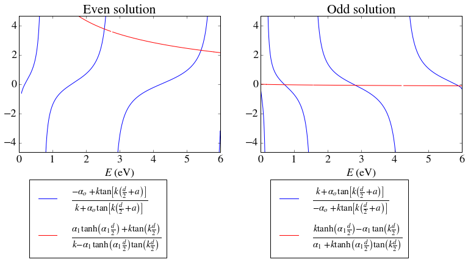

```python
# Reading the input variables from the user and making sure V1 > Vo
Vo = abs(float(input("Enter the value for Vo (in eV) = ")))
a = abs(float(input("Enter the value for a (box size, in Angstroms) = ")))
V1 = 0.9*Vo
while(V1<Vo):
    V1 = float(input("Enter the value for V1 (V1 >= Vo, in eV) = "))
    if(V1<Vo):
        print "V1 cannot be higher than Vo. Please enter the value for V1 again.\n"
d = abs(float(input("Enter the value for d (barrier size, in Angstroms) = ")))

val = np.sqrt(2.0*9.10938356e-31*1.60217662e-19)*1e-10/(1.05457180013e-34) # equal to sqrt(2m*1eV)*1A/hbar

# Defining functions that come from the energy expression
def f0(E):
    var = -np.sqrt(Vo-E)+np.sqrt(E)*np.tan(np.sqrt(E)*val*(d/2.0+a))
    var = var/(np.sqrt(E)+np.sqrt(Vo-E)*np.tan(np.sqrt(E)*val*(d/2.0+a)))
    return var

def f1(E):
    var = np.sqrt(V1-E)*np.tanh(d*np.sqrt(V1-E)*val/2.0)+np.sqrt(E)*np.tan(d*np.sqrt(E)*val/2.0)
    var = var/(np.sqrt(E)-np.sqrt(V1-E)*np.tanh(d*np.sqrt(V1-E)*val/2.0)*np.tan(d*np.sqrt(E)*val/2.0))
    return var

def f2(E):
    var = np.sqrt(E)+np.sqrt(Vo-E)*np.tan(np.sqrt(E)*val*(d/2.0+a))
    var = var/(np.sqrt(E)*np.tan(np.sqrt(E)*val*(d/2.0+a))-np.sqrt(Vo-E))
    return var

def f3(E):
    var = np.sqrt(E)*np.tanh(d*np.sqrt(V1-E)*val/2.0)-np.sqrt(V1-E)*np.tan(d*np.sqrt(E)*val/2.0)
    var = var/(np.sqrt(V1-E)+np.sqrt(E)*np.tanh(d*np.sqrt(V1-E)*val/2.0)*np.tan(d*np.sqrt(E)*val/2.0))
    return var

# Generating the wavefunction graph
plt.rcParams.update({'font.size': 18, 'font.family': 'STIXGeneral', 'mathtext.fontset': 'stix'})
fig, axes = plt.subplots(1, 2, figsize=(13,4))
axes[0].axis([0.0,Vo,-np.sqrt(Vo)*1.9,np.sqrt(Vo)*1.9])
axes[0].set_xlabel(r'$E$ (eV)')
axes[0].set_ylabel(r'')
axes[0].set_title('Even solution')
axes[1].axis([0.0,Vo,-np.sqrt(Vo)*1.9,np.sqrt(Vo)*1.9])
axes[1].set_xlabel(r'$E$ (eV)')
axes[1].set_ylabel(r'')
axes[1].set_title('Odd solution')
E_even = np.linspace(0.0, Vo, 10000)
E_odd = np.linspace(0.0, Vo, 10000)
# Removing discontinuity points
for n in range(10000):
    if abs(np.sqrt(E_even[n])+np.sqrt(Vo-E_even[n])*np.tan(np.sqrt(E_even[n])*val*(d/2.0+a)))<0.1: E_even[n] = np.nan
    if abs(np.sqrt(E_even[n])-np.sqrt(V1-E_even[n])*np.tanh(d*np.sqrt(V1-E_even[n])*val/2.0)*np.tan(d*np.sqrt(E_even[n])*val/2.0))<0.1: E_even[n] = np.nan
    if abs(np.sqrt(E_odd[n])*np.tan(np.sqrt(E_odd[n])*val*(d/2.0+a))-np.sqrt(Vo-E_odd[n]))<0.1: E_odd[n] = np.nan
    if abs(np.sqrt(V1-E_odd[n])+np.sqrt(E_odd[n])*np.tanh(d*np.sqrt(V1-E_odd[n])*val/2.0)*np.tan(d*np.sqrt(E_odd[n])*val/2.0))<0.1: E_odd[n] = np.nan
# Plotting the curves and setting the labelsaxes[0].plot(E_even, f0(E_even), label=r"$\frac{-\alpha_o+k\tan\left[k\left(\frac{d}{2}+a\right)\right]}{k+\alpha_o\tan\left[k\left(\frac{d}{2}+a\right)\right]}$", color="blue")
axes[0].plot(E_even, f0(E_even), label=r"$\frac{-\alpha_o+k\tan\left[k\left(\frac{d}{2}+a\right)\right]}{k+\alpha_o\tan\left[k\left(\frac{d}{2}+a\right)\right]}$", color="blue")
axes[0].plot(E_even, f1(E_even), label=r"$\frac{\alpha_1\tanh\left(\alpha_1\frac{d}{2}\right)+k\tan\left(k\frac{d}{2}\right)}{k-\alpha_1\tanh\left(\alpha_1\frac{d}{2}\right)\tan\left(k\frac{d}{2}\right)}$", color="red")
axes[1].plot(E_odd,  f2(E_odd),  label=r"$\frac{k+\alpha_o\tan\left[k\left(\frac{d}{2}+a\right)\right]}{-\alpha_o+k\tan\left[k\left(\frac{d}{2}+a\right)\right]}$", color="blue")
axes[1].plot(E_odd,  f3(E_odd),  label=r"$\frac{k\tanh\left(\alpha_1\frac{d}{2}\right)-\alpha_1\tan\left(k\frac{d}{2}\right)}{\alpha_1+k\tanh\left(\alpha_1\frac{d}{2}\right)\tan\left(k\frac{d}{2}\right)}$", color="red")
# Chosing the positions of the legends
axes[0].legend(bbox_to_anchor=(0.05, -0.2), loc=2, borderaxespad=0.0)
axes[1].legend(bbox_to_anchor=(0.05, -0.2), loc=2, borderaxespad=0.0)

# Show the plots on the screen once the code reaches this point
plt.show()
```

The allowed values would then be the values of $E$ in which the two curves cross. Here are some question to think about:

- **Q1:** How many bound states there are?
- **Q2:** How many bound states are even and how many are odd?
- **Q3:** Does the ground state has an even or an odd wavefunction?
- **Q4:** Can you read accuretely the allowed values of energy from these graphs?

The allowed values of $E$ can be found by numerically, yielding:

```python
print "The allowed bounded energies are:"
# We want to find the values of E in which f_even and f_odd are zero
f_even = lambda E : f0(E)-f1(E)
f_odd = lambda E : f2(E)-f3(E)
E_old = 0.0
f_even_old = f_even(0.0)
f_odd_old = f_odd(0.0)
n_even = 1
n_odd = 1
E_vals = np.zeros(999)
n = 1
# Here we loop from E = 0 to E = Vo seeking roots
for E in np.linspace(0.0, Vo, 20000):
    f_even_now = f_even(E)
    # If the difference is zero or if it changes sign then we might have passed through a root
    if (f_even_now == 0.0 or f_even_now/f_even_old < 0.0):
        # If the old values of f are not close to zero, this means we didn't pass through a root but
        # through a discontinuity point
        if (abs(f_even_now)<1.0 and abs(f_even_old)<1.0):
            E_vals[n-1] = (E+E_old)/2.0
            print "  State #%3d (Even): %9.4f eV, %13.6g J" % (n,E_vals[n-1],E_vals[n-1]*1.60217662e-19)
            n += 1
            n_even += 1
    f_odd_now = f_odd(E)
    # If the difference is zero or if it changes sign then we might have passed through a root
    if (f_odd_now == 0.0 or f_odd_now/f_odd_old < 0.0) and (E>0.0):
        # If the old values of f are not close to zero, this means we didn't pass through a root but
        # through a discontinuity point
        if (abs(f_odd_now)<1.0 and abs(f_odd_old)<1.0):
            E_vals[n-1] = (E+E_old)/2.0
            print "  State #%3d  (Odd): %9.4f eV, %13.6g J" % (n,E_vals[n-1],E_vals[n-1]*1.60217662e-19)
            n += 1
            n_odd += 1
    E_old = E
    f_even_old = f_even_now
    f_odd_old = f_odd_now
nstates = n-1
print "\nTHERE ARE %3d POSSIBLE BOUNDED ENERGIES" % nstates
```

```
The allowed bounded energies are:
  State #  1 (Even):    0.6491 eV,   1.03994e-19 J
  State #  2  (Odd):    0.7226 eV,   1.15771e-19 J
  State #  3 (Even):    2.5464 eV,   4.07975e-19 J
  State #  4  (Odd):    2.8374 eV,     4.546e-19 J
  State #  5 (Even):    5.4286 eV,   8.69761e-19 J
  State #  6  (Odd):    5.9101 eV,    9.4691e-19 J

THERE ARE   6 POSSIBLE BOUNDED ENERGIES
```

**Plotting an Energy Diagram helps us to see the energy separation between the states.**

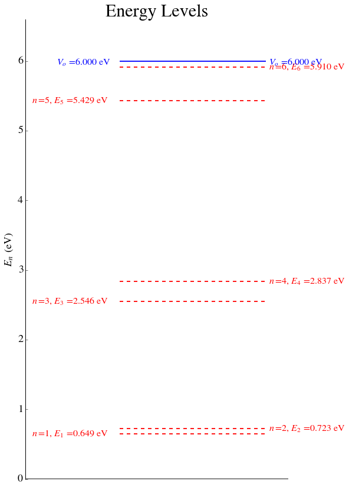

```python
# Generating the energy diagram
fig, ax = plt.subplots(figsize=(8,14))
ax.spines['right'].set_color('none')
ax.yaxis.tick_left()
ax.spines['bottom'].set_color('none')
ax.axes.get_xaxis().set_visible(False)
ax.spines['top'].set_color('none')
ax.axis([0.0,20.0,0.0,1.1*Vo])
ax.set_ylabel(r'$E_n$ (eV)')
for n in range(1,nstates+1):
    str1="$n = "+str(n)+r"$, $E_"+str(n)+r" = %.3f$ eV"%(E_vals[n-1])
    if(n%2==1):
        ax.text(0.5, E_vals[n-1]-0.005*Vo, str1, fontsize=16, color="red")
        ax.hlines(E_vals[n-1], 7.2, 18.3, linewidth=1.8, linestyle='--', color="red")
    else:
        ax.text(18.5, E_vals[n-1]-0.005*Vo, str1, fontsize=16, color="red")
        ax.hlines(E_vals[n-1], 7.2, 18.3, linewidth=1.8, linestyle='--', color="red")
str1="$V_o = %.3f$ eV"%(Vo)
ax.text(18.5, Vo-0.01*Vo, str1, fontsize=16, color="blue")
ax.text(2.4, Vo-0.01*Vo, str1, fontsize=16, color="blue")
ax.hlines(Vo, 7.2, 18.3, linewidth=1.8, linestyle='-', color="blue")
ax.hlines(0.0, 0.0, 20.0, linewidth=1.8, linestyle='-', color="black")
plt.title("Energy Levels", fontsize=30)
plt.show()
```

Notice how the energy levels are *grouped* in pairs ($E_1 \approx E_2$, $E_3\approx E_4$, etc) energetically very close to each other. As the quantum number increases, the difference in energy between two *nearby* states increases.

Once we have the allowed energies, we can go back into the wavefunction expressions and plot the **wavefunctions** and the corresponding **probability densities**.

```
The Wavefunctions are:
```

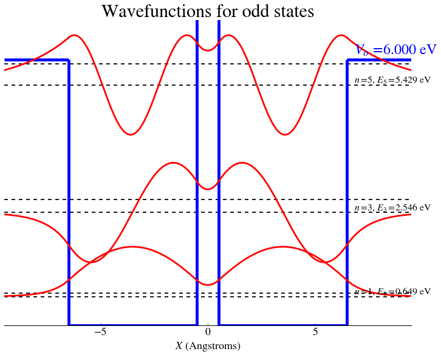

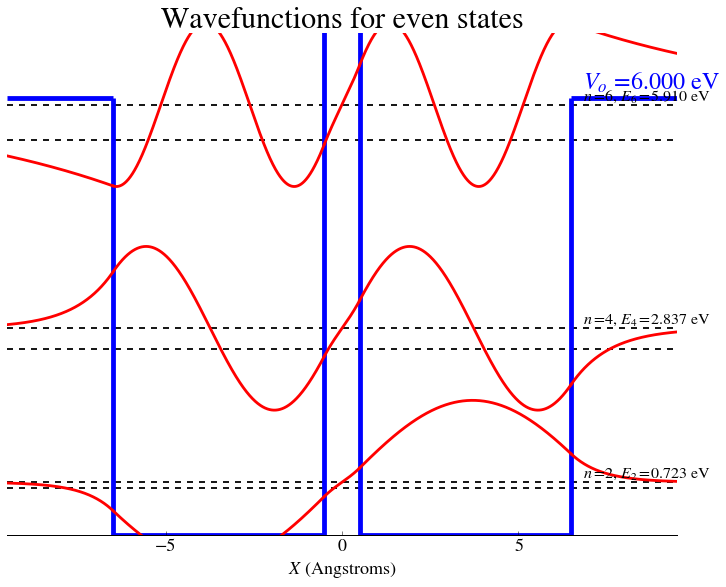

```python
print "\nThe Wavefunctions are:"

# Drawing the backgroung graph
fig, ax = plt.subplots(figsize=(12,9))
ax.spines['right'].set_color('none')
ax.xaxis.tick_bottom()
ax.spines['left'].set_color('none')
ax.axes.get_yaxis().set_visible(False)
ax.spines['top'].set_color('none')
ax.axis([-1.5*a-d/2.0,1.5*a+d/2.0,0.0,1.15*Vo])
ax.set_xlabel(r'$X$ (Angstroms)')
str1="$V_o = %.3f$ eV"%(Vo)
ax.text(1.05*(a+d/2.0), 1.02*Vo, str1, fontsize=24, color="blue")
# Defining the maximum amplitude of the wavefunction
if ((E_vals[1]-E_vals[0])/(E_vals[2]-E_vals[0]) < 0.2):
    amp = np.sqrt((E_vals[2]-E_vals[0])/1.5)
else:
    amp = np.sqrt((E_vals[1]-E_vals[0])/1.5)
# Plotting the energy levels
for n in range(1,nstates+1):
    ax.hlines(E_vals[n-1], -1.5*a-d/2.0, 1.5*a+d/2.0, linewidth=1.8, linestyle='--', color="black")
ax.margins(0.00)
ax.vlines(-a-d/2.0, 0.0, Vo, linewidth=4.8, color="blue")
if(d>0.0):
    ax.vlines(-d/2.0, 0.0, V1, linewidth=4.8, color="blue")
    ax.vlines(d/2.0, 0.0, V1, linewidth=4.8, color="blue")
ax.vlines(a+d/2.0, 0.0, Vo, linewidth=4.8, color="blue")
ax.hlines(Vo, -1.5*a-d/2.0, -a-d/2.0, linewidth=4.8, color="blue")
ax.hlines(0.0, -a-d/2.0, -d/2.0, linewidth=4.8, color="blue")
ax.hlines(V1, -d/2.0, d/2.0, linewidth=4.8, color="blue")
ax.hlines(0.0, d/2.0, a+d/2.0, linewidth=4.8, color="blue")
ax.hlines(Vo, a+d/2.0, 1.5*a+d/2.0, linewidth=4.8, color="blue")
plt.title('Wavefunctions for odd states', fontsize=30)
plt.legend(bbox_to_anchor=(0.8, 1), loc=2, borderaxespad=0.)

# Defining the X ranges
X_lef2 = np.linspace(-1.5*a-d/2.0, -a-d/2.0, 900,endpoint=True)
X_lef1 = np.linspace(-a-d/2.0, -d/2.0, 900,endpoint=True)
X_mid = np.linspace(-d/2.0, d/2.0, 900,endpoint=True)
X_rig1 = np.linspace(d/2.0, a+d/2.0, 900,endpoint=True)
X_rig2 = np.linspace(a+d/2.0, 1.5*a+d/2.0, 900,endpoint=True)

# Plotting the probability densities
for n in range(1,nstates+1):
    k = np.sqrt(E_vals[n-1])*val
    a0 = np.sqrt(Vo-E_vals[n-1])*val
    a1 = np.sqrt(V1-E_vals[n-1])*val
    str1="$n = "+str(n)+r"$, $E_{"+str(n)+r"} = %.3f$ eV"%(E_vals[n-1])
    # Even wavefunction
    if (n%2==1):
        B = amp/np.sqrt(f1(E_vals[n-1])*f1(E_vals[n-1])+1.0)
        C = f1(E_vals[n-1])*B
        A = (B*np.cos(k*d/2.0)+C*np.sin(k*d/2.0))/(np.exp(-a1*d/2.0)+np.exp(a1*d/2.0))
        D = np.exp(a0*(a+d/2.0))*(B*np.cos(k*(a+d/2.0))+C*np.sin(k*(a+d/2.0)))
        ax.plot(X_lef2, E_vals[n-1]+D*np.exp(a0*X_lef2), color="red", label="", linewidth=2.8)
        ax.plot(X_lef1, E_vals[n-1]+B*np.cos(k*X_lef1)-C*np.sin(k*X_lef1), color="red", label="", linewidth=2.8)
        ax.plot(X_mid,  E_vals[n-1]+A*(np.exp(-a1*X_mid)+np.exp(a1*X_mid)), color="red", label="", linewidth=2.8)
        ax.plot(X_rig1, E_vals[n-1]+B*np.cos(k*X_rig1)+C*np.sin(k*X_rig1), color="red", label="", linewidth=2.8)
        ax.plot(X_rig2, E_vals[n-1]+D*np.exp(-a0*X_rig2), color="red", label="", linewidth=2.8)
        ax.text(1.05*(a+d/2.0), E_vals[n-1]+0.01*Vo, str1, fontsize=16, color="black")

plt.show()

# Drawing the backgroung graph
fig, ax = plt.subplots(figsize=(12,9))
ax.spines['right'].set_color('none')
ax.xaxis.tick_bottom()
ax.spines['left'].set_color('none')
ax.axes.get_yaxis().set_visible(False)
ax.spines['top'].set_color('none')
ax.axis([-1.5*a-d/2.0,1.5*a+d/2.0,0.0,1.15*Vo])
ax.set_xlabel(r'$X$ (Angstroms)')
str1="$V_o = %.3f$ eV"%(Vo)
ax.text(1.05*(a+d/2.0), 1.02*Vo, str1, fontsize=24, color="blue")
# Defining the maximum amplitude of the wavefunction
if ((E_vals[1]-E_vals[0])/(E_vals[2]-E_vals[0]) < 0.2):
    amp = np.sqrt((E_vals[2]-E_vals[0])/1.5)
else:
    amp = np.sqrt((E_vals[1]-E_vals[0])/1.5)
# Plotting the energy levels
for n in range(1,nstates+1):
    ax.hlines(E_vals[n-1], -1.5*a-d/2.0, 1.5*a+d/2.0, linewidth=1.8, linestyle='--', color="black")
ax.margins(0.00)
ax.vlines(-a-d/2.0, 0.0, Vo, linewidth=4.8, color="blue")
if(d>0.0):
    ax.vlines(-d/2.0, 0.0, V1, linewidth=4.8, color="blue")
    ax.vlines(d/2.0, 0.0, V1, linewidth=4.8, color="blue")
ax.vlines(a+d/2.0, 0.0, Vo, linewidth=4.8, color="blue")
ax.hlines(Vo, -1.5*a-d/2.0, -a-d/2.0, linewidth=4.8, color="blue")
ax.hlines(0.0, -a-d/2.0, -d/2.0, linewidth=4.8, color="blue")
ax.hlines(V1, -d/2.0, d/2.0, linewidth=4.8, color="blue")
ax.hlines(0.0, d/2.0, a+d/2.0, linewidth=4.8, color="blue")
ax.hlines(Vo, a+d/2.0, 1.5*a+d/2.0, linewidth=4.8, color="blue")
plt.title('Wavefunctions for even states', fontsize=30)
plt.legend(bbox_to_anchor=(0.8, 1), loc=2, borderaxespad=0.)

# Defining the X ranges
X_lef2 = np.linspace(-1.5*a-d/2.0, -a-d/2.0, 900,endpoint=True)
X_lef1 = np.linspace(-a-d/2.0, -d/2.0, 900,endpoint=True)
X_mid = np.linspace(-d/2.0, d/2.0, 900,endpoint=True)
X_rig1 = np.linspace(d/2.0, a+d/2.0, 900,endpoint=True)
X_rig2 = np.linspace(a+d/2.0, 1.5*a+d/2.0, 900,endpoint=True)

# Plotting the probability densities
for n in range(1,nstates+1):
    k = np.sqrt(E_vals[n-1])*val
    a0 = np.sqrt(Vo-E_vals[n-1])*val
    a1 = np.sqrt(V1-E_vals[n-1])*val
    str1="$n = "+str(n)+r"$, $E_{"+str(n)+r"} = %.3f$ eV"%(E_vals[n-1])
    # Odd wavefunction
    if (n%2==0):
        C = amp/np.sqrt(f3(E_vals[n-1])*f3(E_vals[n-1])+1.0)
        B = f3(E_vals[n-1])*C
        A = (B*np.cos(k*d/2.0)+C*np.sin(k*d/2.0))/(-np.exp(-a1*d/2.0)+np.exp(a1*d/2.0))
        D = np.exp(a0*(a+d/2.0))*(B*np.cos(k*(a+d/2.0))+C*np.sin(k*(a+d/2.0)))
        ax.plot(X_lef2, E_vals[n-1]-D*np.exp(a0*X_lef2), color="red", label="", linewidth=2.8)
        ax.plot(X_lef1, E_vals[n-1]-B*np.cos(k*X_lef1)+C*np.sin(k*X_lef1), color="red", label="", linewidth=2.8)
        ax.plot(X_mid,  E_vals[n-1]+A*(-np.exp(-a1*X_mid)+np.exp(a1*X_mid)), color="red", label="", linewidth=2.8)
        ax.plot(X_rig1, E_vals[n-1]+B*np.cos(k*X_rig1)+C*np.sin(k*X_rig1), color="red", label="", linewidth=2.8)
        ax.plot(X_rig2, E_vals[n-1]+D*np.exp(-a0*X_rig2), color="red", label="", linewidth=2.8)
        ax.text(1.05*(a+d/2.0), E_vals[n-1]+0.01*Vo, str1, fontsize=16, color="black")

plt.show()
```

```
The Probability Densities are:
```

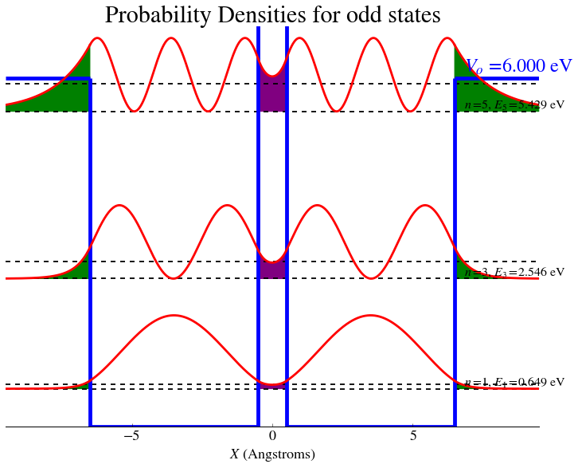

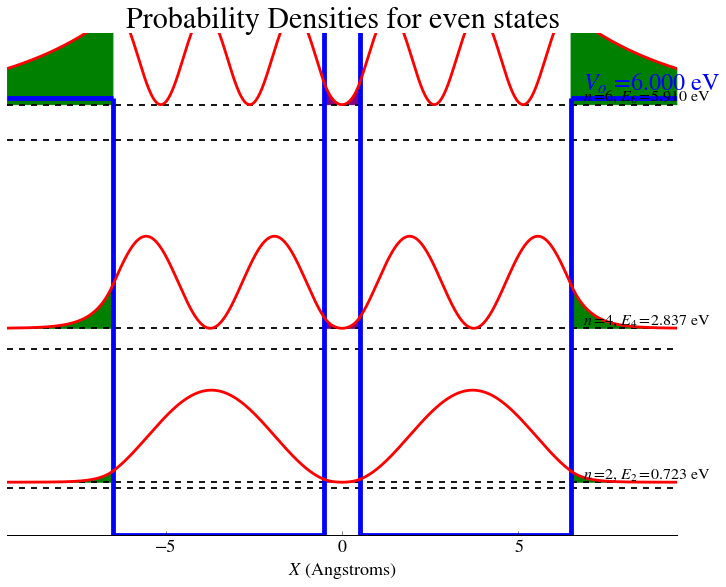

```python
print "\nThe Probability Densities are:"

# Drawing the backgroung graph
fig, ax = plt.subplots(figsize=(12,9))
ax.spines['right'].set_color('none')
ax.xaxis.tick_bottom()
ax.spines['left'].set_color('none')
ax.axes.get_yaxis().set_visible(False)
ax.spines['top'].set_color('none')
ax.axis([-1.5*a-d/2.0,1.5*a+d/2.0,0.0,1.15*Vo])
ax.set_xlabel(r'$X$ (Angstroms)')
str1="$V_o = %.3f$ eV"%(Vo)
ax.text(1.05*(a+d/2.0), 1.02*Vo, str1, fontsize=24, color="blue")
# Defining the maximum amplitude of the wavefunction
if ((E_vals[1]-E_vals[0])/(E_vals[2]-E_vals[0]) < 0.2):
    amp = np.sqrt((E_vals[2]-E_vals[0])/1.5)
else:
    amp = np.sqrt((E_vals[1]-E_vals[0])/1.5)
# Plotting the energy levels
for n in range(1,nstates+1):
    ax.hlines(E_vals[n-1], -1.5*a-d/2.0, 1.5*a+d/2.0, linewidth=1.8, linestyle='--', color="black")
ax.margins(0.00)
ax.vlines(-a-d/2.0, 0.0, Vo, linewidth=4.8, color="blue")
if(d>0.0):
    ax.vlines(-d/2.0, 0.0, V1, linewidth=4.8, color="blue")
    ax.vlines(d/2.0, 0.0, V1, linewidth=4.8, color="blue")
ax.vlines(a+d/2.0, 0.0, Vo, linewidth=4.8, color="blue")
ax.hlines(Vo, -1.5*a-d/2.0, -a-d/2.0, linewidth=4.8, color="blue")
ax.hlines(0.0, -a-d/2.0, -d/2.0, linewidth=4.8, color="blue")
ax.hlines(V1, -d/2.0, d/2.0, linewidth=4.8, color="blue")
ax.hlines(0.0, d/2.0, a+d/2.0, linewidth=4.8, color="blue")
ax.hlines(Vo, a+d/2.0, 1.5*a+d/2.0, linewidth=4.8, color="blue")
plt.title('Probability Densities for odd states', fontsize=30)
plt.legend(bbox_to_anchor=(0.8, 1), loc=2, borderaxespad=0.)

# Defining the X ranges
X_lef2 = np.linspace(-1.5*a-d/2.0, -a-d/2.0, 900,endpoint=True)
X_lef1 = np.linspace(-a-d/2.0, -d/2.0, 900,endpoint=True)
X_mid = np.linspace(-d/2.0, d/2.0, 900,endpoint=True)
X_rig1 = np.linspace(d/2.0, a+d/2.0, 900,endpoint=True)
X_rig2 = np.linspace(a+d/2.0, 1.5*a+d/2.0, 900,endpoint=True)

# Plotting the probability densities
for n in range(1,nstates+1):
    k = np.sqrt(E_vals[n-1])*val
    a0 = np.sqrt(Vo-E_vals[n-1])*val
    a1 = np.sqrt(V1-E_vals[n-1])*val
    str1="$n = "+str(n)+r"$, $E_{"+str(n)+r"} = %.3f$ eV"%(E_vals[n-1])
    # Even wavefunction
    if (n%2==1):
        B = amp/np.sqrt(f1(E_vals[n-1])*f1(E_vals[n-1])+1.0)
        C = f1(E_vals[n-1])*B
        A = (B*np.cos(k*d/2.0)+C*np.sin(k*d/2.0))/(np.exp(-a1*d/2.0)+np.exp(a1*d/2.0))
        D = np.exp(a0*(a+d/2.0))*(B*np.cos(k*(a+d/2.0))+C*np.sin(k*(a+d/2.0)))
        ax.plot(X_lef2, E_vals[n-1]+(D*np.exp(a0*X_lef2))**2, color="red", label="", linewidth=2.8)
        ax.fill_between(X_lef2, E_vals[n-1], E_vals[n-1]+(D*np.exp(a0*X_lef2))**2, color="green")
        ax.plot(X_lef1, E_vals[n-1]+(B*np.cos(k*X_lef1)-C*np.sin(k*X_lef1))**2, color="red", label="", linewidth=2.8)
        ax.plot(X_mid,  E_vals[n-1]+(A*(np.exp(-a1*X_mid)+np.exp(a1*X_mid)))**2, color="red", label="", linewidth=2.8)
        ax.fill_between(X_mid, E_vals[n-1], E_vals[n-1]+(A*(np.exp(-a1*X_mid)+np.exp(a1*X_mid)))**2, color="purple")
        ax.plot(X_rig1, E_vals[n-1]+(B*np.cos(k*X_rig1)+C*np.sin(k*X_rig1))**2, color="red", label="", linewidth=2.8)
        ax.plot(X_rig2, E_vals[n-1]+(D*np.exp(-a0*X_rig2))**2, color="red", label="", linewidth=2.8)
        ax.fill_between(X_rig2, E_vals[n-1], E_vals[n-1]+(D*np.exp(-a0*X_rig2))**2, color="green")
        ax.text(1.05*(a+d/2.0), E_vals[n-1]+0.01*Vo, str1, fontsize=16, color="black")

plt.show()

# Drawing the backgroung graph
fig, ax = plt.subplots(figsize=(12,9))
ax.spines['right'].set_color('none')
ax.xaxis.tick_bottom()
ax.spines['left'].set_color('none')
ax.axes.get_yaxis().set_visible(False)
ax.spines['top'].set_color('none')
ax.axis([-1.5*a-d/2.0,1.5*a+d/2.0,0.0,1.15*Vo])
ax.set_xlabel(r'$X$ (Angstroms)')
str1="$V_o = %.3f$ eV"%(Vo)
ax.text(1.05*(a+d/2.0), 1.02*Vo, str1, fontsize=24, color="blue")
# Defining the maximum amplitude of the wavefunction
if ((E_vals[1]-E_vals[0])/(E_vals[2]-E_vals[0]) < 0.2):
    amp = np.sqrt((E_vals[2]-E_vals[0])/1.5)
else:
    amp = np.sqrt((E_vals[1]-E_vals[0])/1.5)
# Plotting the energy levels
for n in range(1,nstates+1):
    ax.hlines(E_vals[n-1], -1.5*a-d/2.0, 1.5*a+d/2.0, linewidth=1.8, linestyle='--', color="black")
ax.margins(0.00)
ax.vlines(-a-d/2.0, 0.0, Vo, linewidth=4.8, color="blue")
if(d>0.0):
    ax.vlines(-d/2.0, 0.0, V1, linewidth=4.8, color="blue")
    ax.vlines(d/2.0, 0.0, V1, linewidth=4.8, color="blue")
ax.vlines(a+d/2.0, 0.0, Vo, linewidth=4.8, color="blue")
ax.hlines(Vo, -1.5*a-d/2.0, -a-d/2.0, linewidth=4.8, color="blue")
ax.hlines(0.0, -a-d/2.0, -d/2.0, linewidth=4.8, color="blue")
ax.hlines(V1, -d/2.0, d/2.0, linewidth=4.8, color="blue")
ax.hlines(0.0, d/2.0, a+d/2.0, linewidth=4.8, color="blue")
ax.hlines(Vo, a+d/2.0, 1.5*a+d/2.0, linewidth=4.8, color="blue")
plt.title('Probability Densities for even states', fontsize=30)
plt.legend(bbox_to_anchor=(0.8, 1), loc=2, borderaxespad=0.)

# Defining the X ranges
X_lef2 = np.linspace(-1.5*a-d/2.0, -a-d/2.0, 900,endpoint=True)
X_lef1 = np.linspace(-a-d/2.0, -d/2.0, 900,endpoint=True)
X_mid = np.linspace(-d/2.0, d/2.0, 900,endpoint=True)
X_rig1 = np.linspace(d/2.0, a+d/2.0, 900,endpoint=True)
X_rig2 = np.linspace(a+d/2.0, 1.5*a+d/2.0, 900,endpoint=True)

# Plotting the probability densities
for n in range(1,nstates+1):
    k = np.sqrt(E_vals[n-1])*val
    a0 = np.sqrt(Vo-E_vals[n-1])*val
    a1 = np.sqrt(V1-E_vals[n-1])*val
    str1="$n = "+str(n)+r"$, $E_{"+str(n)+r"} = %.3f$ eV"%(E_vals[n-1])
    # Odd wavefunction
    if (n%2==0):
        C = amp/np.sqrt(f3(E_vals[n-1])*f3(E_vals[n-1])+1.0)
        B = f3(E_vals[n-1])*C
        A = (B*np.cos(k*d/2.0)+C*np.sin(k*d/2.0))/(-np.exp(-a1*d/2.0)+np.exp(a1*d/2.0))
        D = np.exp(a0*(a+d/2.0))*(B*np.cos(k*(a+d/2.0))+C*np.sin(k*(a+d/2.0)))
        ax.plot(X_lef2, E_vals[n-1]+(D*np.exp(a0*X_lef2))**2, color="red", label="", linewidth=2.8)
        ax.fill_between(X_lef2, E_vals[n-1], E_vals[n-1]+(D*np.exp(a0*X_lef2))**2, color="green")
        ax.plot(X_lef1, E_vals[n-1]+(-B*np.cos(k*X_lef1)+C*np.sin(k*X_lef1))**2, color="red", label="", linewidth=2.8)
        ax.plot(X_mid,  E_vals[n-1]+(A*(-np.exp(-a1*X_mid)+np.exp(a1*X_mid)))**2, color="red", label="", linewidth=2.8)
        ax.fill_between(X_mid, E_vals[n-1], E_vals[n-1]+(A*(-np.exp(-a1*X_mid)+np.exp(a1*X_mid)))**2, color="purple")
        ax.plot(X_rig1, E_vals[n-1]+(B*np.cos(k*X_rig1)+C*np.sin(k*X_rig1))**2, color="red", label="", linewidth=2.8)
        ax.plot(X_rig2, E_vals[n-1]+(D*np.exp(-a0*X_rig2))**2, color="red", label="", linewidth=2.8)
        ax.fill_between(X_rig2, E_vals[n-1], E_vals[n-1]+(D*np.exp(-a0*X_rig2))**2, color="green")
        ax.text(1.05*(a+d/2.0), E_vals[n-1]+0.01*Vo, str1, fontsize=16, color="black")

plt.show()
```

This extremely simplified model can help us understand the bonding and anti-bonding behavior observed in diatomic molecules. When we consider constribution from two equivalent wavefunctions (one corresponding to the left side box and the other correspoding to the right side box) we observed the formation of pair of nearby states which correlate to individual states in uncoupled boxes. Their combined contribution can result into constructive interference, leading to a higher probability density of finding the particle between the two boxes, or to destructive interference, with a node between the two boxes. As the distance between boxes changes (try repeating the calculations and graphics using a different barrier width) the coupling between the two boxes changes; increasing for short distances and decreasing for boxes further apart. When the barrier is wide enough, the two boxes behave as independent boxes, with some probability of tunneling into the barrier, but without the splitting of the energy levels or the consequences of wave interference.

The tunneling probability (areas shaded in green in the cell above) correspond to the area under the probability densities outside both boxes, that is, for $x \geq \frac{d}{2}+a$ and for $x \leq -\frac{d}{2}-a$. It corresponds to: $$ \frac{\int^{-\frac{d}{2}-a}_{-\infty} |\psi(x)|^2\ dx +\int^{+\infty}_{\frac{d}{2}+a} |\psi(x)|^2\ dx }{\int_{-\infty}^{+\infty} |\psi(x)|^2\ dx }$$

It is also interesting to evaluate the probability of finding the particle inside the barrier (area shaded in purple in the cell above), that is, between $-\frac{d}{2} \leq x \leq \frac{d}{2}$. This probability equals to: $$ \frac{\int_{-\frac{d}{2}}^{\frac{d}{2}} |\psi(x)|^2\ dx}{\int_{-\infty}^{+\infty} |\psi(x)|^2\ dx }$$

These integrals can be solved analytically (for the even and for the odd solutions). After doing that, the tunneling probability and probability of being inside the barrier for each state is:

```python
print "\nThe tunneling probabilities and probabilities of being inside the barrier are:"
for n in range(1,nstates+1):
    k = np.sqrt(E_vals[n-1])*val
    a0 = np.sqrt(Vo-E_vals[n-1])*val
    a1 = np.sqrt(V1-E_vals[n-1])*val
    # Odd wavefunction
    if (n%2==0):
        C = 1.0
        B = f3(E_vals[n-1])*C
        D = np.exp(a0*(a+d/2.0))*(B*np.cos(k*(a+d/2.0))+C*np.sin(k*(a+d/2.0)))
        tunn_prob = D*D*np.exp(-a0*(2.0*a+d))/(2.0*a0)
        total_prob = tunn_prob
        if (d>0.0):
            A = (B*np.cos(k*d/2.0)+C*np.sin(k*d/2.0))/(-np.exp(-a1*d/2.0)+np.exp(a1*d/2.0))
            barr_prob = A*A*(np.sinh(a1*d)/a1-d)
            total_prob += barr_prob
        else:
            barr_prob = 0.0
        total_prob += (B*B*(np.sin(k*(2.0*a+d))+2.0*a*k-np.sin(k*d))+2.0*B*C*(np.cos(k*d)-np.cos(k*(2.0*a+d)))+C*C*(-np.sin(k*(2.0*a+d))+2.0*a*k+np.sin(k*d)))/(4.0*k)
        print "  State #%3d  (Odd): tunneling probability = %5.2f%%, barrier probability = %5.2f%%" % (n,100*tunn_prob/total_prob,100*barr_prob/total_prob)
    # Even wavefunction
    else:
        B = 1.0
        C = f1(E_vals[n-1])*B
        A = (B*np.cos(k*d/2.0)+C*np.sin(k*d/2.0))/(np.exp(-a1*d/2.0)+np.exp(a1*d/2.0))
        D = np.exp(a0*(a+d/2.0))*(B*np.cos(k*(a+d/2.0))+C*np.sin(k*(a+d/2.0)))
        barr_prob = A*A*(np.sinh(a1*d)/a1+d)
        tunn_prob = D*D*np.exp(-a0*(2.0*a+d))/(2.0*a0)
        total_prob = barr_prob + tunn_prob
        total_prob += (B*B*(np.sin(k*(2.0*a+d))+2.0*a*k-np.sin(k*d))+2.0*B*C*(np.cos(k*d)-np.cos(k*(2.0*a+d)))+C*C*(-np.sin(k*(2.0*a+d))+2.0*a*k+np.sin(k*d)))/(4.0*k)
        print "  State #%3d (Even): tunneling probability = %5.2f%%, barrier probability = %5.2f%%" % (n,100*tunn_prob/total_prob,100*barr_prob/total_prob)
```

```
The tunneling probabilities and probabilities of being inside the barrier are:
  State #  1 (Even): tunneling probability =  1.19%, barrier probability =  0.91%
  State #  2  (Odd): tunneling probability =  1.41%, barrier probability =  0.13%
  State #  3 (Even): tunneling probability =  5.63%, barrier probability =  3.40%
  State #  4  (Odd): tunneling probability =  6.92%, barrier probability =  0.48%
  State #  5 (Even): tunneling probability = 24.56%, barrier probability =  5.80%
  State #  6  (Odd): tunneling probability = 49.63%, barrier probability =  0.57%
```